# Práticas sobre Manipulação e Tratamento de dados

## 7.3 Reordenar por ordem numérica

### 7.3.1 ordem crescente

Utilizando a função `arrange()`, do pacote `dplyr`, é possível escolher a ordem numérica. O padrão da função é uma ordem crescente, então basta apenas a variável.

```r
iris %>%
  arrange(Sepal.Length)
```

```
##     Sepal.Length Sepal.Width Petal.Length Petal.Width    Species
## 1            4.3         3.0          1.1         0.1     setosa
## 2            4.4         2.9          1.4         0.2     setosa
## 3            4.4         3.0          1.3         0.2     setosa
## 4            4.4         3.2          1.3         0.2     setosa
## 5            4.5         2.3          1.3         0.3     setosa
## 6            4.6         3.1          1.5         0.2     setosa
## 7            4.6         3.4          1.4         0.3     setosa
## 8            4.6         3.6          1.0         0.2     setosa
## 9            4.6         3.2          1.4         0.2     setosa
## 10           4.7         3.2          1.3         0.2     setosa
## 11           4.7         3.2          1.6         0.2     setosa
## 12           4.8         3.4          1.6         0.2     setosa
## 13           4.8         3.0          1.4         0.1     setosa
## 14           4.8         3.4          1.9         0.2     setosa
```

[output cut: 136 more lines]

### 7.3.2 Ordem decrescente

Como a ordem crescente é o padrão da função `arrange()`, usa-se o comando `desc()` para informar que a ordem é decrescente. Note que a espécie *Iris virginica*, que anntes estava nas últimas linhas, agora está nas primeiras.

```r
iris %>%
  arrange(desc(Sepal.Length))
```

```
##     Sepal.Length Sepal.Width Petal.Length Petal.Width    Species
## 1            7.9         3.8          6.4         2.0  virginica
## 2            7.7         3.8          6.7         2.2  virginica
## 3            7.7         2.6          6.9         2.3  virginica
## 4            7.7         2.8          6.7         2.0  virginica
## 5            7.7         3.0          6.1         2.3  virginica
## 6            7.6         3.0          6.6         2.1  virginica
## 7            7.4         2.8          6.1         1.9  virginica
## 8            7.3         2.9          6.3         1.8  virginica
## 9            7.2         3.6          6.1         2.5  virginica
## 10           7.2         3.2          6.0         1.8  virginica
## 11           7.2         3.0          5.8         1.6  virginica
## 12           7.1         3.0          5.9         2.1  virginica
## 13           7.0         3.2          4.7         1.4 versicolor
## 14           6.9         3.1          4.9         1.5 versicolor
```

[output cut: 136 more lines]

## 7.4 Ordem alfabética

### 7.4.1 A-Z

Assim como em uma ordenação númerica, o padrão da ordenação alfabética é a ordenação A-Z. Uma coisa muito útil da função `arrange()` é que ela identifica a natureza dos valores, se estes são numéricos, de texto ou fatores, assim fazendo o tipo de reordenação correta na variável.

```r
starwars %>%
  arrange(name)
```

```
## # A tibble: 87 × 14
##    name        height  mass hair_…¹ skin_…² eye_c…³ birth…⁴ sex   gender homew…⁵
##    <chr>        <int> <dbl> <chr>   <chr>   <chr>     <dbl> <chr> <chr>  <chr>
##  1 Ackbar         180    83 none    brown … orange     41   male  mascu… Mon Ca…
##  2 Adi Gallia     184    50 none    dark    blue       NA   fema… femin… Corusc…
##  3 Anakin Sky…    188    84 blond   fair    blue       41.9 male  mascu… Tatooi…
##  4 Arvel Cryn…     NA    NA brown   fair    brown      NA   male  mascu… <NA>
##  5 Ayla Secura    178    55 none    blue    hazel      48   fema… femin… Ryloth
##  6 Bail Prest…    191    NA black   tan     brown      67   male  mascu… Aldera…
##  7 Barriss Of…    166    50 black   yellow  blue       40   fema… femin… Mirial
##  8 BB8             NA    NA none    none    black      NA   none  mascu… <NA>
##  9 Ben Quadin…    163    65 none    grey, … orange     NA   male  mascu… Tund
## 10 Beru White…    165    75 brown   light   blue       47   fema… femin… Tatooi…
## # … with 77 more rows, 4 more variables: species <chr>, films <list>,
## #   vehicles <list>, starships <list>, and abbreviated variable names
## #   ¹hair_color, ²skin_color, ³eye_color, ⁴birth_year, ⁵homeworld
```

### 7.4.2 Z-A

Novamente, basta apenas utilizar o comando `desc()`.

```r
starwars %>%
  arrange(desc(name))
```

```
## # A tibble: 87 × 14
##    name        height  mass hair_…¹ skin_…² eye_c…³ birth…⁴ sex   gender homew…⁵
##    <chr>        <int> <dbl> <chr>   <chr>   <chr>     <dbl> <chr> <chr>  <chr>
##  1 Zam Wesell     168    55 blonde  fair, … yellow       NA fema… femin… Zolan
##  2 Yoda            66    17 white   green   brown       896 male  mascu… <NA>
##  3 Yarael Poof    264    NA none    white   yellow       NA male  mascu… Quermia
##  4 Wilhuff Ta…    180    NA auburn… fair    blue         64 male  mascu… Eriadu
##  5 Wicket Sys…     88    20 brown   brown   brown         8 male  mascu… Endor
##  6 Wedge Anti…    170    77 brown   fair    hazel        21 male  mascu… Corell…
##  7 Watto          137    NA black   blue, … yellow       NA male  mascu… Toydar…
##  8 Wat Tambor     193    48 none    green,… unknown      NA male  mascu… Skako
##  9 Tion Medon     206    80 none    grey    black        NA male  mascu… Utapau
## 10 Taun We        213    NA none    grey    black        NA fema… femin… Kamino
## # … with 77 more rows, 4 more variables: species <chr>, films <list>,
## #   vehicles <list>, starships <list>, and abbreviated variable names
## #   ¹hair_color, ²skin_color, ³eye_color, ⁴birth_year, ⁵homeworld
```

## 7.5 Outras órdens desejadas

Os métodos apresentados são úteis quando o reordenamento segue uma ordem, mas em outras ordens, que não seguem as regras apresentadas, estas funções não são muito úteis. Desta forma, para outros reordenamentos, é necessário usar outros comando, estes mais básicos. Nesse caso, vamos dividir o dataset original em outros, de acordo com os valores da variável desejada, com a função `filter()`, do pacote `dplyr`.

Primeiro, serão visualizados quais os valores da variável `hair_color`, do dataset `starwars`, através da transformação em fator e em seguido verificando os níveis.

```r
starwars$hair_color %>% as.factor() %>% levels()
```

```
##  [1] "auburn"        "auburn, grey"  "auburn, white" "black"
##  [5] "blond"         "blonde"        "brown"         "brown, grey"
##  [9] "grey"          "none"          "unknown"       "white"
```

Após saber quais os os valores, pode-se ser feitos datasets separados.

```r
auburn<-starwars %>%
  filter(hair_color=="auburn")

`auburn, grey`<-starwars %>%
  filter(hair_color=="auburn, grey")

`auburn, white`<-starwars %>%
  filter(hair_color=="auburn, white")

black<-starwars %>%
  filter(hair_color=="black")

blond<-starwars %>%
  filter(hair_color=="blond")

blonde<-starwars %>%
  filter(hair_color=="blonde")

brown<-starwars %>%
  filter(hair_color=="brown")

`brown, grey`<-starwars %>%
  filter(hair_color=="brown, grey")

grey<-starwars %>%
  filter(hair_color=="grey")

none<-starwars %>%
  filter(hair_color=="none")

unknown<-starwars %>%
  filter(hair_color=="unknown")

white<-starwars %>%
  filter(hair_color=="white")

`NA`<-starwars %>%
  filter(is.na(hair_color))
```

Como nesta situaçao foram muitos valores, então muito objetos a serem criados, vale se lembrar que, ao invés de digitar o código todo, poupa tempo apenas cópiar e colar o comando, apenas alterando os parâmetros necessários, como o nome do objeto e da variável. Também vale ressaltar que as linhas contendo dados NA precisam tambem serem selecionadas, pois sem elas, havaeria perda de linhas de outras variável, e assim, perdendo informação. Por isso, lembre-se sempre de verificar a existância de dados NA, podendo utilizar a função `is.na()`. Com os objetos gerados, deve-se unir as linhas desses objetos, através da função `rbind()`. Essa função juntas as linhas indicadas dentro da função, na sequência dos indicada dos objetos na função

```r
starwars_reoganizado<-rbind(blond,blonde,auburn,`auburn, grey`,`auburn, white`,brown,`brown, grey`,black,grey,white,unknown,none,`NA`) # juntando as linhas

starwars_reoganizado # conferindo os dados
```

```
## # A tibble: 87 × 14
##    name        height  mass hair_…¹ skin_…² eye_c…³ birth…⁴ sex   gender homew…⁵
##    <chr>        <int> <dbl> <chr>   <chr>   <chr>     <dbl> <chr> <chr>  <chr>
##  1 Luke Skywa…    172    77 blond   fair    blue       19   male  mascu… Tatooi…
##  2 Anakin Sky…    188    84 blond   fair    blue       41.9 male  mascu… Tatooi…
##  3 Finis Valo…    170    NA blond   fair    blue       91   male  mascu… Corusc…
##  4 Zam Wesell     168    55 blonde  fair, … yellow     NA   fema… femin… Zolan
##  5 Mon Mothma     150    NA auburn  fair    blue       48   fema… femin… Chandr…
##  6 Wilhuff Ta…    180    NA auburn… fair    blue       64   male  mascu… Eriadu
##  7 Obi-Wan Ke…    182    77 auburn… fair    blue-g…    57   male  mascu… Stewjon
##  8 Leia Organa    150    49 brown   light   brown      19   fema… femin… Aldera…
##  9 Beru White…    165    75 brown   light   blue       47   fema… femin… Tatooi…
## 10 Chewbacca      228   112 brown   unknown blue      200   male  mascu… Kashyy…
## # … with 77 more rows, 4 more variables: species <chr>, films <list>,
## #   vehicles <list>, starships <list>, and abbreviated variable names
## #   ¹hair_color, ²skin_color, ³eye_color, ⁴birth_year, ⁵homeworld
```

Antes de finalizar a operação, vale o cuidado de conferir se o nº de linhas do dataset criado bate com o dataset original, para garantir que não houve perda de dados.

```r
nrow(starwars)==nrow(starwars_reoganizado)
```

```
## [1] TRUE
```

Como foi possível observar, os números de linhas batem, então rejeita-se a hipótese que ocorreu perda de dados no processo. Uma coisa interessante desse método, é que ele também pode ser utilizado para reordenar a ordem das variável, substituindo apenas o `filter()` por `select()`, e o `rbind()` por `cbind()`.

# 8 **Controlando os fatores**

Fatores são um tipo de dado categórico do R. Diferente dos dados de texto (`charater`), os fatores (`factor`) representam variáveis categóricas, numericamente. Diferente dos dados de texto, os fatores não ficam representados por aspas, e possuem níveis, que representam uma “hierarquia” dos fatores. Algumas operações do R exigem que os dados estejam como fator. O principal pacote para trabalhar com os fatores é o `forcats`, que também faz parte do `tidyverse`.

## 8.1 Pacotes exigidos

```r
library(tidyverse)
```

## 8.2 Carregando os datasets utilizados

```r
data(starwars) # Dataset sobre personagens da franquia Starwars

starwars # Visualizando os dados
```

```
## # A tibble: 87 × 14
##    name        height  mass hair_…¹ skin_…² eye_c…³ birth…⁴ sex   gender homew…⁵
##    <chr>        <int> <dbl> <chr>   <chr>   <chr>     <dbl> <chr> <chr>  <chr>
##  1 Luke Skywa…    172    77 blond   fair    blue       19   male  mascu… Tatooi…
##  2 C-3PO          167    75 <NA>    gold    yellow    112   none  mascu… Tatooi…
##  3 R2-D2           96    32 <NA>    white,… red        33   none  mascu… Naboo
##  4 Darth Vader    202   136 none    white   yellow     41.9 male  mascu… Tatooi…
##  5 Leia Organa    150    49 brown   light   brown      19   fema… femin… Aldera…
##  6 Owen Lars      178   120 brown,… light   blue       52   male  mascu… Tatooi…
##  7 Beru White…    165    75 brown   light   blue       47   fema… femin… Tatooi…
##  8 R5-D4           97    32 <NA>    white,… red        NA   none  mascu… Tatooi…
##  9 Biggs Dark…    183    84 black   light   brown      24   male  mascu… Tatooi…
## 10 Obi-Wan Ke…    182    77 auburn… fair    blue-g…    57   male  mascu… Stewjon
## # … with 77 more rows, 4 more variables: species <chr>, films <list>,
## #   vehicles <list>, starships <list>, and abbreviated variable names
## #   ¹hair_color, ²skin_color, ³eye_color, ⁴birth_year, ⁵homeworld
```

```r
data(iris) # Dataset sobre comprimento e largura de sempalas e de pétalas de 3 espécies de plantas

iris # Visualizando os dados
```

```
##     Sepal.Length Sepal.Width Petal.Length Petal.Width    Species
## 1            5.1         3.5          1.4         0.2     setosa
## 2            4.9         3.0          1.4         0.2     setosa
## 3            4.7         3.2          1.3         0.2     setosa
## 4            4.6         3.1          1.5         0.2     setosa
## 5            5.0         3.6          1.4         0.2     setosa
## 6            5.4         3.9          1.7         0.4     setosa
## 7            4.6         3.4          1.4         0.3     setosa
## 8            5.0         3.4          1.5         0.2     setosa
## 9            4.4         2.9          1.4         0.2     setosa
## 10           4.9         3.1          1.5         0.1     setosa
## 11           5.4         3.7          1.5         0.2     setosa
## 12           4.8         3.4          1.6         0.2     setosa
## 13           4.8         3.0          1.4         0.1     setosa
## 14           4.3         3.0          1.1         0.1     setosa
```

[output cut: 136 more lines]

## 8.3 Transformando em fator

É possível transformar um dado de texto em fator. Para isso, primeiro é preciso saber se os dados estão em fator. Existem duas principais formas de fazer isso.

```r
# Método class()

starwars$name %>%
  class()
```

```
## [1] "character"
```

```r
# Método is.factor()

starwars$name %>%
  is.factor()
```

```
## [1] FALSE
```

Como mostrado, os dados não estão em fator. Pra transformar em fator, usa-se a função **as.factor()**.

```r
starwars$name %>%
  as.factor() %>%
  is.factor()
```

```
## [1] TRUE
```

Como foi possível observar, os dados foram transformmados em fatores.

## 8.4 Alterando os fatores

Também é possível redefinir os fatores utilizados, através da função `fact_recode()`. Para mostrar essas difernaças na prática, vamos utilizar o ggplot, da função `ggplot()`, do pacote `ggplot2`. Para saber mais sobre o ggplot, [clique aqui nesse outro RPubs](https://rpubs.com/Edbbio/974391).

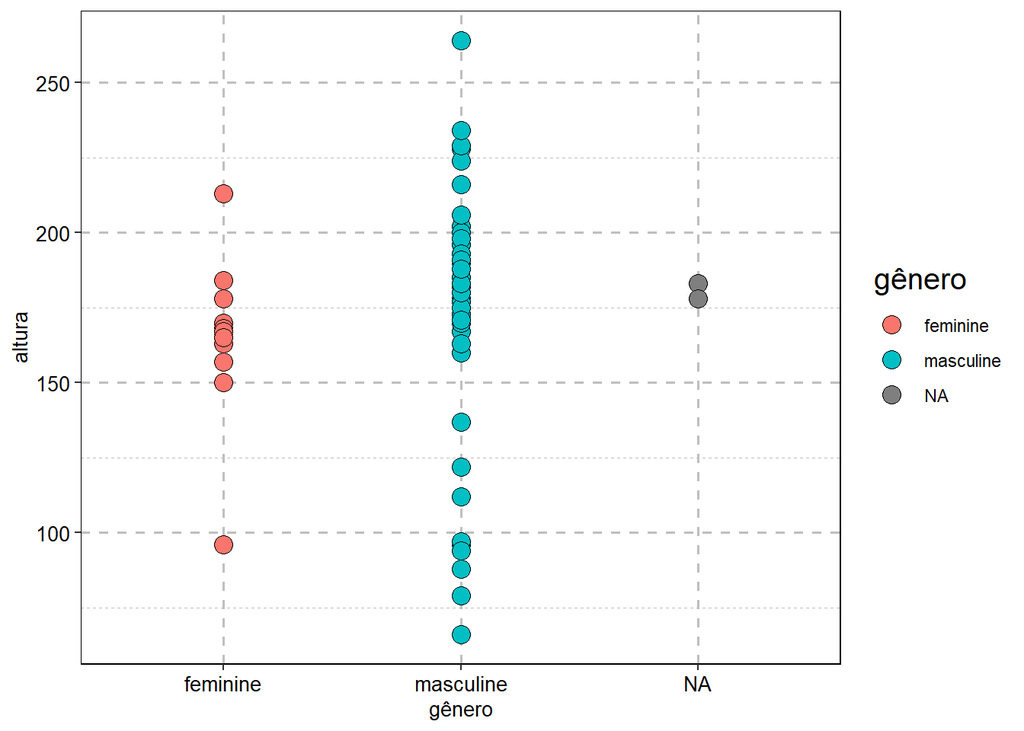

```r
starwars %>%
  ggplot(aes(gender,height,fill=gender))+
  geom_point(shape=21,color="black",size=4)+
  labs(x="gênero",
       y="altura",
       fill="gênero")+
  theme(text=element_text(family="TimesNewRoman"),
            title=element_text(color="black",size=15),
            axis.text = element_text(color="black",size=10),
            axis.title = element_text(color="black",size=10),
            panel.grid=element_line(color="grey75",linetype="dashed",size=0.7),
            axis.line=element_blank(),
            plot.background=element_rect(fill="white",color="white"),
            panel.background=element_rect(fill="white"),
            panel.border = element_rect(colour = "black",fill=NA,size=0.5),
            legend.key= element_rect(color="white",fill="white"))
```

Agora os fatores serão alterados.

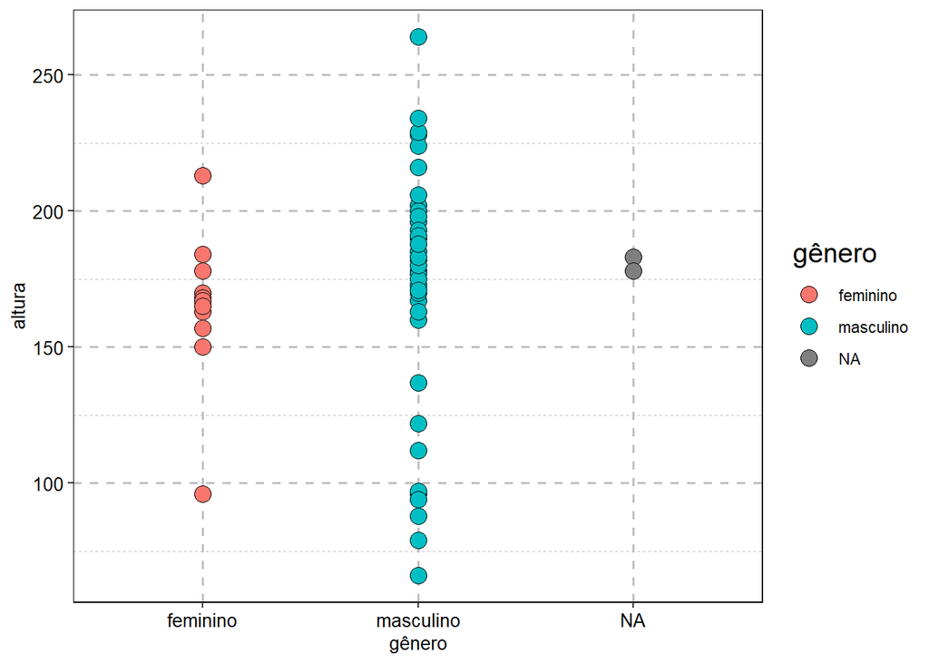

```r
# Alterando os fatores

starwars$gender<-starwars$gender %>%
  as.factor() %>%
  fct_recode(masculino="masculine",
             feminino="feminine")

# Criando o ggplot

starwars %>%
  ggplot(aes(gender,height,fill=gender))+
  geom_point(shape=21,color="black",size=4)+
  labs(x="gênero",
       y="altura",
       fill="gênero")+
  theme(text=element_text(family="TimesNewRoman"),
            title=element_text(color="black",size=15),
            axis.text = element_text(color="black",size=10),
            axis.title = element_text(color="black",size=10),
            panel.grid=element_line(color="grey75",linetype="dashed",size=0.7),
            axis.line=element_blank(),
            plot.background=element_rect(fill="white",color="white"),
            panel.background=element_rect(fill="white"),
            panel.border = element_rect(colour = "black",fill=NA,size=0.5),
            legend.key= element_rect(color="white",fill="white"))
```

## 8.5 Alterando os níveis dos fatores

Para mostrar como os fatores se distribuem natural e de forma alfabética, é útil utilizar um ggplot.

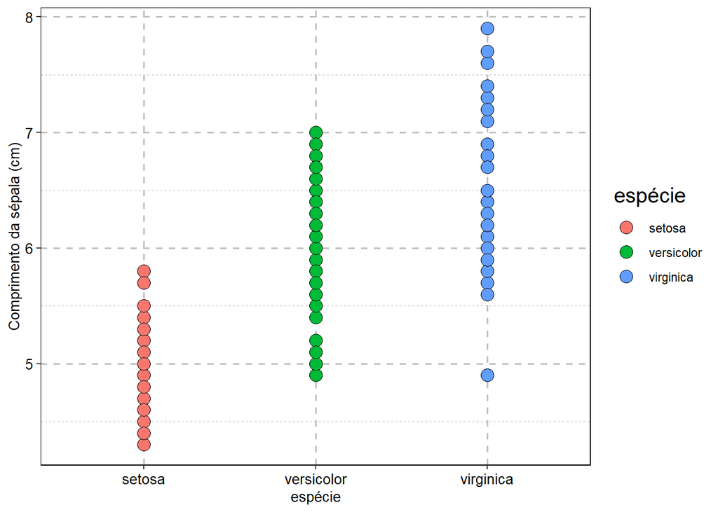

```r
iris %>%
  ggplot(aes(Species,Sepal.Length,fill=Species))+
  geom_point(shape=21,color="black",size=4)+
  labs(x="espécie",
       y="Comprimento da sépala (cm)",
       fill="espécie")+
  theme(text=element_text(family="TimesNewRoman"),
            title=element_text(color="black",size=15),
            axis.text = element_text(color="black",size=10),
            axis.title = element_text(color="black",size=10),
            panel.grid=element_line(color="grey75",linetype="dashed",size=0.7),
            axis.line=element_blank(),
            plot.background=element_rect(fill="white",color="white"),
            panel.background=element_rect(fill="white"),
            panel.border = element_rect(colour = "black",fill=NA,size=0.5),
            legend.key= element_rect(color="white",fill="white"))
```

### 8.5.1 Ordem decrescente ou Z-A

Existem algumas formas de reorganizar estas sequências de níveis. Uma forma é reorganizar em ordem decrescente ou Z-A, através da função `fct_rev()`.

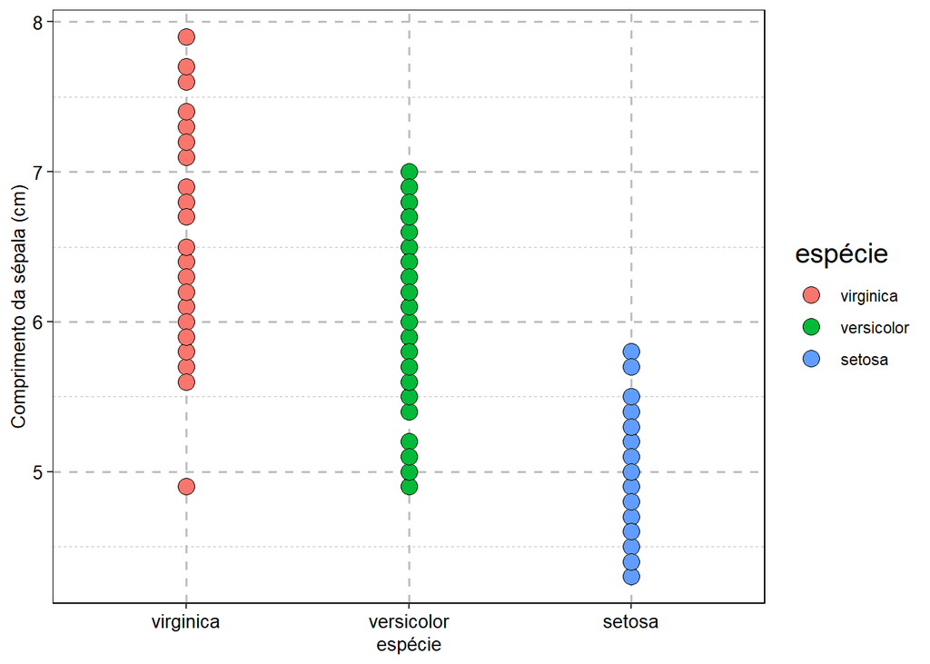

```r
# Alterando a ordem alfebética para Z-A

iris$Species<-iris$Species %>%
  fct_rev()

# Criando o ggplot

iris %>%
  ggplot(aes(Species,Sepal.Length,fill=Species))+
  geom_point(shape=21,color="black",size=4)+
  labs(x="espécie",
       y="Comprimento da sépala (cm)",
       fill="espécie")+
  theme(text=element_text(family="TimesNewRoman"),
            title=element_text(color="black",size=15),
            axis.text = element_text(color="black",size=10),
            axis.title = element_text(color="black",size=10),
            panel.grid=element_line(color="grey75",linetype="dashed",size=0.7),
            axis.line=element_blank(),
            plot.background=element_rect(fill="white",color="white"),
            panel.background=element_rect(fill="white"),
            panel.border = element_rect(colour = "black",fill=NA,size=0.5),
            legend.key= element_rect(color="white",fill="white"))
```

### 8.5.2 Ordem específica

Caso seja alguma ordem específica, é possível fazer utilizando a função `fct_relevel()`.

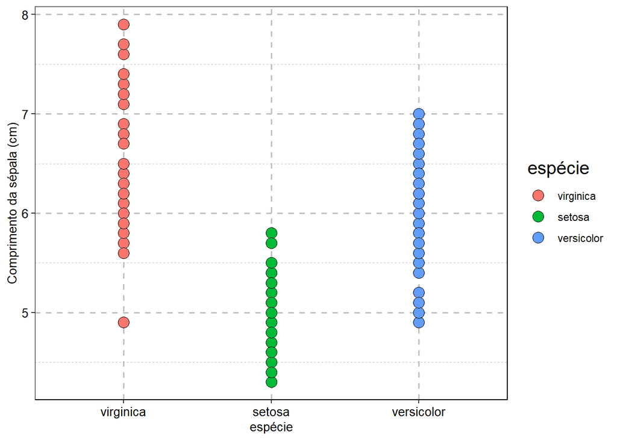

```r
# Reordenando os níveis

iris$Species<-iris$Species %>%
  fct_relevel("virginica",
              "setosa",
              "versicolor")

# Criando o ggplot

iris %>%
  ggplot(aes(Species,Sepal.Length,fill=Species))+
  geom_point(shape=21,color="black",size=4)+
  labs(x="espécie",
       y="Comprimento da sépala (cm)",
       fill="espécie")+
  theme(text=element_text(family="TimesNewRoman"),
            title=element_text(color="black",size=15),
            axis.text = element_text(color="black",size=10),
            axis.title = element_text(color="black",size=10),
            panel.grid=element_line(color="grey75",linetype="dashed",size=0.7),
            axis.line=element_blank(),
            plot.background=element_rect(fill="white",color="white"),
            panel.background=element_rect(fill="white"),
            panel.border = element_rect(colour = "black",fill=NA,size=0.5),
            legend.key= element_rect(color="white",fill="white"))
```

# 9 **Selecionando linhas por hierarquia dos valores**

Há situações onde o que se deseja é saber as nº primeiras ou últimas ocorrências dos maiores ou menores dados de uma variável, os elementos de uma variável categórica que representam os nº maiores ou menores valores de um variável contínua ou até quantas vezes aparecem os os elementos de uma variável categórica que representam os nº maiores ou menores valores de um variável contínua. Dentro das data sciences, situações podem se tornar rotineiras, e parte da tomada de decisão, seja no mundo dos negócios ou em pesquisas científicas. Para fazer essas operações, bastam apenas funções bastante básicas, algumas já vistas aqui, apenas combinadas em sequência.

## 9.1 Pacotes exigidos

```r
library(tidyverse)
library(palmerpenguins) # para extrair os dados de pinguins
```

## 9.2 Carregando os datasets utilizados

```r
data(starwars) # Dataset sobre personagens da franquia Starwars

starwars # Visualizando os dados
```

```
## # A tibble: 87 × 14
##    name        height  mass hair_…¹ skin_…² eye_c…³ birth…⁴ sex   gender homew…⁵
##    <chr>        <int> <dbl> <chr>   <chr>   <chr>     <dbl> <chr> <chr>  <chr>
##  1 Luke Skywa…    172    77 blond   fair    blue       19   male  mascu… Tatooi…
##  2 C-3PO          167    75 <NA>    gold    yellow    112   none  mascu… Tatooi…
##  3 R2-D2           96    32 <NA>    white,… red        33   none  mascu… Naboo
##  4 Darth Vader    202   136 none    white   yellow     41.9 male  mascu… Tatooi…
##  5 Leia Organa    150    49 brown   light   brown      19   fema… femin… Aldera…
##  6 Owen Lars      178   120 brown,… light   blue       52   male  mascu… Tatooi…
##  7 Beru White…    165    75 brown   light   blue       47   fema… femin… Tatooi…
##  8 R5-D4           97    32 <NA>    white,… red        NA   none  mascu… Tatooi…
##  9 Biggs Dark…    183    84 black   light   brown      24   male  mascu… Tatooi…
## 10 Obi-Wan Ke…    182    77 auburn… fair    blue-g…    57   male  mascu… Stewjon
## # … with 77 more rows, 4 more variables: species <chr>, films <list>,
## #   vehicles <list>, starships <list>, and abbreviated variable names
## #   ¹hair_color, ²skin_color, ³eye_color, ⁴birth_year, ⁵homeworld
```

```r
data(penguins) # Medidas de tamanho para pinguins forrageiros adultos de pinguins perto da Estação Palmer, Antártica

penguins # Visualizando os dados
```

```
## # A tibble: 344 × 8
##    species island    bill_length_mm bill_depth_mm flipper_…¹ body_…² sex    year
##    <fct>   <fct>              <dbl>         <dbl>      <int>   <int> <fct> <int>
##  1 Adelie  Torgersen           39.1          18.7        181    3750 male   2007
##  2 Adelie  Torgersen           39.5          17.4        186    3800 fema…  2007
##  3 Adelie  Torgersen           40.3          18          195    3250 fema…  2007
##  4 Adelie  Torgersen           NA            NA           NA      NA <NA>   2007
##  5 Adelie  Torgersen           36.7          19.3        193    3450 fema…  2007
##  6 Adelie  Torgersen           39.3          20.6        190    3650 male   2007
##  7 Adelie  Torgersen           38.9          17.8        181    3625 fema…  2007
##  8 Adelie  Torgersen           39.2          19.6        195    4675 male   2007
##  9 Adelie  Torgersen           34.1          18.1        193    3475 <NA>   2007
## 10 Adelie  Torgersen           42            20.2        190    4250 <NA>   2007
## # … with 334 more rows, and abbreviated variable names ¹flipper_length_mm,
## #   ²body_mass_g
```

## 9.3 Selecionando as n observações com os maiores valores de uma variável

Essa é o tipo de situação em que você precisa extrair os maiores valores de uma variável, normalmente combinando com uma variável categórica, para saber dessa variável categórica quai os elementos que aparecem. Um exemplo seria verificar dentro de um dataset sobre nº de espécies de anfíbios em diversos fragmentos de mata atlântica, quais os fragmentos correspondem às 5 maiores observações do nº de anfíbios.

### 9.3.1 Método `arrange()`

Esse exemplo, serão selecionadas as ocorrências com as ilhas com as 30 maiores ocorrências do massa corporal das três espécies de pinguins, através das variável `island` e `body_mass_g`, do dataset `penguins`. Aqui, será utilizada a função `arrange`, para uma ordem numérica decrescente, atribuída a um novo objeto e então extraído as 30 primeiras linhas.

```r
pinguins_30_max<-penguins %>%
  arrange(desc(body_mass_g)) # Criando o novo dataset

pinguins_30_max[1:30,] %>%
  select(body_mass_g) # Vizualizando as 30 primeiras observações
```

```
## # A tibble: 30 × 1
##    body_mass_g
##          <int>
##  1        6300
##  2        6050
##  3        6000
##  4        6000
##  5        5950
##  6        5950
##  7        5850
##  8        5850
##  9        5850
## 10        5800
## # … with 20 more rows
```

Para melhor vizualizar, será feito um gráfico com a função `ggplot()`, do pacote `ggplot2`.

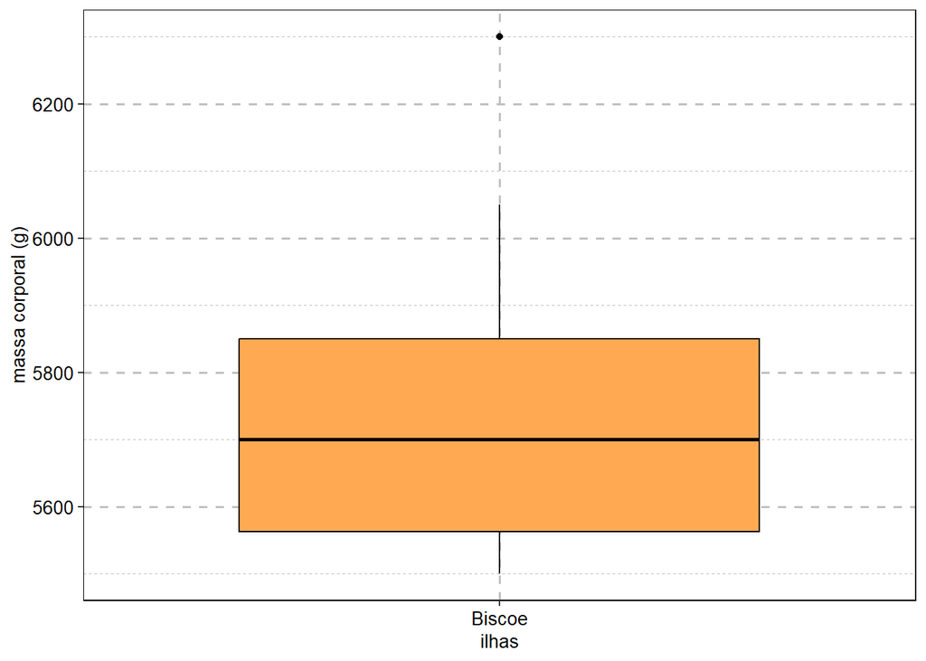

```r
pinguins_30_max[1:30,] %>%
  ggplot(aes(island,body_mass_g))+
  geom_boxplot(color="black",fill="#FFAA52")+
  labs(x="ilhas",
       y="massa corporal (g)")+
  theme(text=element_text(family="TimesNewRoman"),
            title=element_text(color="black",size=15),
            axis.text = element_text(color="black",size=10),
            axis.title = element_text(color="black",size=10),
            panel.grid=element_line(color="grey75",linetype="dashed",size=0.7),
            axis.line=element_blank(),
            plot.background=element_rect(fill="white",color="white"),
            panel.background=element_rect(fill="white"),
            panel.border = element_rect(colour = "black",fill=NA,size=0.5),
            legend.key= element_rect(color="white",fill="white"))
```

### 9.3.2 Método `slice_max()`

O `slice_max()` é uma das funções `slice()`, que retira porções de observações de um dataset, do pacote `dplyr`. Ao contrário do `filter()`, que seleciona todas as possíveis observações baseadas na regra de filtragem, os as funções `slice()` selecionam apenas um número pre-estabelecido de observações, baseado não em regras de filtragem, mas em hierarquia, como as primeiras, as últimas ou as menores observações. A função `slice_max()` todas a n maiores maiores observações de uma variável, onde o n é estabelecido na função. Será feita a mesma coisa feita anteiormente com o dataset `penguins`, mas apenas usando a função `slice_max()`.

```r
penguins %>%
  slice_max(body_mass_g,n=30) %>%
  select(body_mass_g)
```

```
## # A tibble: 33 × 1
##    body_mass_g
##          <int>
##  1        6300
##  2        6050
##  3        6000
##  4        6000
##  5        5950
##  6        5950
##  7        5850
##  8        5850
##  9        5850
## 10        5800
## # … with 23 more rows
```

Usando a função `slice_max()`, é possível fazer exatamente a mesma coisa, porém de forma muito mais simples que no método anterior. Vale ressaltar que, se você selecionar `n=1`, para o `slice_max()`, e houverem mais de uma ocorrência com o mesmo valor, ele retornará todos as observações que possuírem aquele valor, sendo então maior que 1 observação.

## 9.4 Selecionando as n observações com menores valores de uma variável

Esse é exatamente o oposto do tópico anterior. Aqui também será repetido o método com o `arrange()` e uma função `slice()`.

### 9.4.1 Método `arrange()`

Nesse exemplo, serão selecionadas as ocorrências com as ilhas com as 30 menores ocorrências do massa corporal das três espécies de pinguins, através das variável `island` e `body_mass_g`, do dataset `penguins`. Aqui, será utilizada novamente a função `arrange`, mas agora para uma ordem numérica crescente, atribuída a um novo objeto e então extraído as 30 primeiras linhas, referentes às 30 menores observações do dataset original.

```r
pinguins_30_min<-penguins %>%
  arrange(body_mass_g) # Criando o novo dataset

pinguins_30_min[1:30,] %>%
  select(body_mass_g) # Vizualizando as 30 primeiras observações
```

```
## # A tibble: 30 × 1
##    body_mass_g
##          <int>
##  1        2700
##  2        2850
##  3        2850
##  4        2900
##  5        2900
##  6        2900
##  7        2900
##  8        2925
##  9        2975
## 10        3000
## # … with 20 more rows
```

Como é possível observar, consegui-se extrair as 30 observações com os menores valores. Novamente, para melhor vizualizar, será feito um gráfico com a função `ggplot()`, do pacote `ggplot2`.

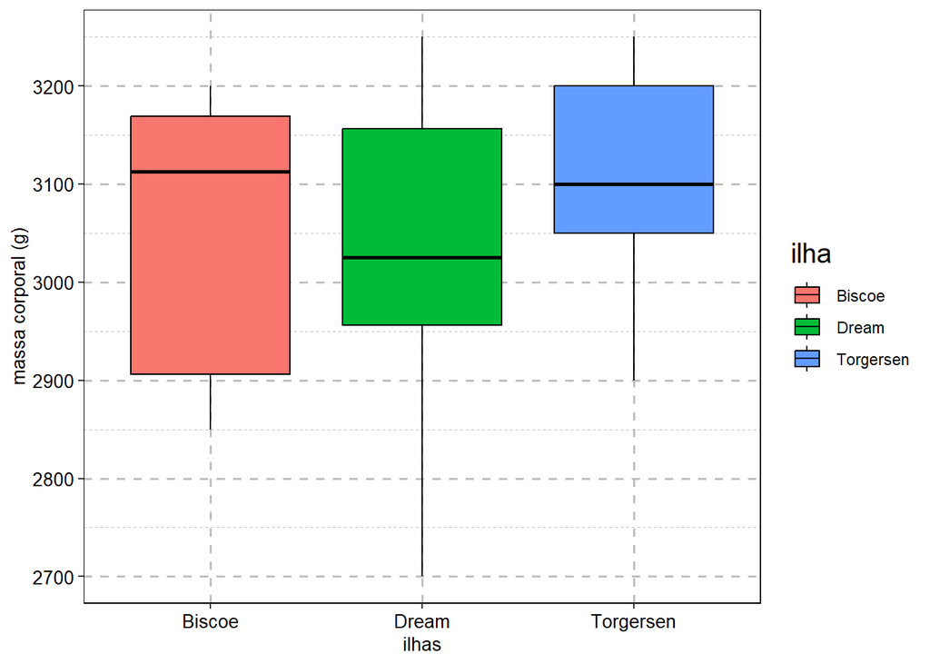

```r
pinguins_30_min[1:30,] %>%
  ggplot(aes(island,body_mass_g,fill=island))+
  geom_boxplot(color="black")+
  labs(x="ilhas",
       y="massa corporal (g)",
       fill="ilha")+
  theme(text=element_text(family="TimesNewRoman"),
            title=element_text(color="black",size=15),
            axis.text = element_text(color="black",size=10),
            axis.title = element_text(color="black",size=10),
            panel.grid=element_line(color="grey75",linetype="dashed",size=0.7),
            axis.line=element_blank(),
            plot.background=element_rect(fill="white",color="white"),
            panel.background=element_rect(fill="white"),
            panel.border = element_rect(colour = "black",fill=NA,size=0.5),
            legend.key= element_rect(color="white",fill="white"))
```

Quando selecionamos as 30 observações os menores valores de massa corporal, é possível obter dados das 3 ilhas.

### 9.4.2 Método `slice_min()`

Esse também faz o oposto da sua “irmã” `slice_max()`: retira uma porção com as n menores observações de um dataset. Aqui também, o n é definido previamente na função. Será feito a mesma operação do tópico anterior, mas com a função `slice_min()`, também do pacote `dplyr`.

```r
penguins %>%
  slice_min(body_mass_g,n=30) %>%
  select(body_mass_g)
```

```
## # A tibble: 33 × 1
##    body_mass_g
##          <int>
##  1        2700
##  2        2850
##  3        2850
##  4        2900
##  5        2900
##  6        2900
##  7        2900
##  8        2925
##  9        2975
## 10        3000
## # … with 23 more rows
```

É uma forma mais simples de extrair as n observações com os menores valores, com menos linhas de código.

## 9.5 Selecionando as primeiras observações de um dataset

Esse é o tipo de situação em que, em mãos de um dataset, você precisa selecionar as primeiras n observações. Um exemplo dessas situações é quando você pegou um dataset que contém os dados de candidatos a um workshop, e ganharia os 40 primeiros que se inscreverem, e o seu dataset tem 185 observaçãoes. Outro cenário é quando você tratou previamente um dataset de notas de candidatos a uma vaga de emprego que passaram por um treinee, reorganizou por órdem decrescente os valores das pontuações dos candidatos (como feito nos tópicos anteriores), e precisa selecionar os candidatos com as 10 maiores pontuações. E se você já praticou ou prestou atenção no capítulo 1 dessa apostila, já deve estar pensando que basta usar o comando `dataset tratado[1:10,]`. Sim, dá pra fazer assim, mas também há algumas funções que fazem isso.

### 9.5.1 Método `head()`

A função `head()`, do pacote nativo `utils`, seleciona as primeiras n obbservações do dataset, onde o n também é especificado na função (daí o nome da função: “cabeça”). Nesse exemplo, serão selecionadas as 15 primeiras observações do dataset `starwars`.

```r
starwars %>%
  head(n=15)
```

```
## # A tibble: 15 × 14
##    name        height  mass hair_…¹ skin_…² eye_c…³ birth…⁴ sex   gender homew…⁵
##    <chr>        <int> <dbl> <chr>   <chr>   <chr>     <dbl> <chr> <chr>  <chr>
##  1 Luke Skywa…    172    77 blond   fair    blue       19   male  mascu… Tatooi…
##  2 C-3PO          167    75 <NA>    gold    yellow    112   none  mascu… Tatooi…
##  3 R2-D2           96    32 <NA>    white,… red        33   none  mascu… Naboo
##  4 Darth Vader    202   136 none    white   yellow     41.9 male  mascu… Tatooi…
##  5 Leia Organa    150    49 brown   light   brown      19   fema… femin… Aldera…
##  6 Owen Lars      178   120 brown,… light   blue       52   male  mascu… Tatooi…
##  7 Beru White…    165    75 brown   light   blue       47   fema… femin… Tatooi…
##  8 R5-D4           97    32 <NA>    white,… red        NA   none  mascu… Tatooi…
##  9 Biggs Dark…    183    84 black   light   brown      24   male  mascu… Tatooi…
## 10 Obi-Wan Ke…    182    77 auburn… fair    blue-g…    57   male  mascu… Stewjon
## 11 Anakin Sky…    188    84 blond   fair    blue       41.9 male  mascu… Tatooi…
## 12 Wilhuff Ta…    180    NA auburn… fair    blue       64   male  mascu… Eriadu
## 13 Chewbacca      228   112 brown   unknown blue      200   male  mascu… Kashyy…
## 14 Han Solo       180    80 brown   fair    brown      29   male  mascu… Corell…
## 15 Greedo         173    74 <NA>    green   black      44   male  mascu… Rodia
## # … with 4 more variables: species <chr>, films <list>, vehicles <list>,
## #   starships <list>, and abbreviated variable names ¹hair_color, ²skin_color,
## #   ³eye_color, ⁴birth_year, ⁵homeworld
```

### 9.5.2 Método `slice_head()`

Essa é mais uma pra lista das funções `slice()`, também do pacote `dplyr`. O funcionamento desta é extamente igual à função anterior. Aqui, também será útilizada o dataset `starwars` para selecionar suas 15 primeiras observaçãoes.

```r
starwars %>%
  slice_head(n=15)
```

```
## # A tibble: 15 × 14
##    name        height  mass hair_…¹ skin_…² eye_c…³ birth…⁴ sex   gender homew…⁵
##    <chr>        <int> <dbl> <chr>   <chr>   <chr>     <dbl> <chr> <chr>  <chr>
##  1 Luke Skywa…    172    77 blond   fair    blue       19   male  mascu… Tatooi…
##  2 C-3PO          167    75 <NA>    gold    yellow    112   none  mascu… Tatooi…
##  3 R2-D2           96    32 <NA>    white,… red        33   none  mascu… Naboo
##  4 Darth Vader    202   136 none    white   yellow     41.9 male  mascu… Tatooi…
##  5 Leia Organa    150    49 brown   light   brown      19   fema… femin… Aldera…
##  6 Owen Lars      178   120 brown,… light   blue       52   male  mascu… Tatooi…
##  7 Beru White…    165    75 brown   light   blue       47   fema… femin… Tatooi…
##  8 R5-D4           97    32 <NA>    white,… red        NA   none  mascu… Tatooi…
##  9 Biggs Dark…    183    84 black   light   brown      24   male  mascu… Tatooi…
## 10 Obi-Wan Ke…    182    77 auburn… fair    blue-g…    57   male  mascu… Stewjon
## 11 Anakin Sky…    188    84 blond   fair    blue       41.9 male  mascu… Tatooi…
## 12 Wilhuff Ta…    180    NA auburn… fair    blue       64   male  mascu… Eriadu
## 13 Chewbacca      228   112 brown   unknown blue      200   male  mascu… Kashyy…
## 14 Han Solo       180    80 brown   fair    brown      29   male  mascu… Corell…
## 15 Greedo         173    74 <NA>    green   black      44   male  mascu… Rodia
## # … with 4 more variables: species <chr>, films <list>, vehicles <list>,
## #   starships <list>, and abbreviated variable names ¹hair_color, ²skin_color,
## #   ³eye_color, ⁴birth_year, ⁵homeworld
```

## 9.6 Selecionando as últimas observações de um dataset

Equanto que para selecionar as n primeiras observações de uma variável é algo quase que “à gosto”, já que há 3 formas de fazer, todas bem simples, o mesmo não acontece com selecionar as n últimas observações de uma variável. Isso acontece porque as 20 primeiras observações de um dataset não dependem do seu tamanho, do seu n de obserações: as 20 primeras observações serão as 20 primeiras, seja seu dataset tendo 50 ou 50000 observações.

Contudo, a situação muda se forem as n últimas linhas, caso você use o comando `dataset[n:n,]`: se você usar `dataset[31:50,]` para um dataset que tenha 50 observações, você terá as 20 últimas observações, mas de você tiver um dataset com 50000 observações, e você fizer o mesmo comando, você não terá as 20 últimas observações. Nessa situação, funções que fazem isso de forma automática são muito úteis e polpam linhas de código.

### 9.6.1 Método `tail()`

A função `tail()` é uma função do pacote `utils`, e que seleciona as n últimas observações de um dataset. Aqui, será feito como nos exemplos anteriores, mas dessa vez, para as 20 últimas observações.

```r
starwars %>%
  tail(n=20)
```

```
## # A tibble: 20 × 14
##    name        height  mass hair_…¹ skin_…² eye_c…³ birth…⁴ sex   gender homew…⁵
##    <chr>        <int> <dbl> <chr>   <chr>   <chr>     <dbl> <chr> <chr>  <chr>
##  1 Dexter Jet…    198   102 none    brown   yellow       NA male  mascu… Ojom
##  2 Lama Su        229    88 none    grey    black        NA male  mascu… Kamino
##  3 Taun We        213    NA none    grey    black        NA fema… femin… Kamino
##  4 Jocasta Nu     167    NA white   fair    blue         NA fema… femin… Corusc…
##  5 Ratts Tyer…     79    15 none    grey, … unknown      NA male  mascu… Aleen …
##  6 R4-P17          96    NA none    silver… red, b…      NA none  femin… <NA>
##  7 Wat Tambor     193    48 none    green,… unknown      NA male  mascu… Skako
##  8 San Hill       191    NA none    grey    gold         NA male  mascu… Muunil…
##  9 Shaak Ti       178    57 none    red, b… black        NA fema… femin… Shili
## 10 Grievous       216   159 none    brown,… green,…      NA male  mascu… Kalee
## 11 Tarfful        234   136 brown   brown   blue         NA male  mascu… Kashyy…
## 12 Raymus Ant…    188    79 brown   light   brown        NA male  mascu… Aldera…
## 13 Sly Moore      178    48 none    pale    white        NA <NA>  <NA>   Umbara
## 14 Tion Medon     206    80 none    grey    black        NA male  mascu… Utapau
## 15 Finn            NA    NA black   dark    dark         NA male  mascu… <NA>
## 16 Rey             NA    NA brown   light   hazel        NA fema… femin… <NA>
## 17 Poe Dameron     NA    NA brown   light   brown        NA male  mascu… <NA>
## 18 BB8             NA    NA none    none    black        NA none  mascu… <NA>
## 19 Captain Ph…     NA    NA unknown unknown unknown      NA <NA>  <NA>   <NA>
## 20 Padmé Amid…    165    45 brown   light   brown        46 fema… femin… Naboo
## # … with 4 more variables: species <chr>, films <list>, vehicles <list>,
## #   starships <list>, and abbreviated variable names ¹hair_color, ²skin_color,
## #   ³eye_color, ⁴birth_year, ⁵homeworld
```

### 9.6.2 Método `slice_tail()`

```r
starwars %>%
  slice_tail(n=20)
```

```
## # A tibble: 20 × 14
##    name        height  mass hair_…¹ skin_…² eye_c…³ birth…⁴ sex   gender homew…⁵
##    <chr>        <int> <dbl> <chr>   <chr>   <chr>     <dbl> <chr> <chr>  <chr>
##  1 Dexter Jet…    198   102 none    brown   yellow       NA male  mascu… Ojom
##  2 Lama Su        229    88 none    grey    black        NA male  mascu… Kamino
##  3 Taun We        213    NA none    grey    black        NA fema… femin… Kamino
##  4 Jocasta Nu     167    NA white   fair    blue         NA fema… femin… Corusc…
##  5 Ratts Tyer…     79    15 none    grey, … unknown      NA male  mascu… Aleen …
##  6 R4-P17          96    NA none    silver… red, b…      NA none  femin… <NA>
##  7 Wat Tambor     193    48 none    green,… unknown      NA male  mascu… Skako
##  8 San Hill       191    NA none    grey    gold         NA male  mascu… Muunil…
##  9 Shaak Ti       178    57 none    red, b… black        NA fema… femin… Shili
## 10 Grievous       216   159 none    brown,… green,…      NA male  mascu… Kalee
## 11 Tarfful        234   136 brown   brown   blue         NA male  mascu… Kashyy…
## 12 Raymus Ant…    188    79 brown   light   brown        NA male  mascu… Aldera…
## 13 Sly Moore      178    48 none    pale    white        NA <NA>  <NA>   Umbara
## 14 Tion Medon     206    80 none    grey    black        NA male  mascu… Utapau
## 15 Finn            NA    NA black   dark    dark         NA male  mascu… <NA>
## 16 Rey             NA    NA brown   light   hazel        NA fema… femin… <NA>
## 17 Poe Dameron     NA    NA brown   light   brown        NA male  mascu… <NA>
## 18 BB8             NA    NA none    none    black        NA none  mascu… <NA>
## 19 Captain Ph…     NA    NA unknown unknown unknown      NA <NA>  <NA>   <NA>
## 20 Padmé Amid…    165    45 brown   light   brown        46 fema… femin… Naboo
## # … with 4 more variables: species <chr>, films <list>, vehicles <list>,
## #   starships <list>, and abbreviated variable names ¹hair_color, ²skin_color,
## #   ³eye_color, ⁴birth_year, ⁵homeworld
```

## 9.7 Selecionando uma amostra aleatória de um dataset

Em situações em que é necessário extrair uma amostra aleatória de um dataset, para escolher locais para fazer coleta de dados, ou para análises estatísticas, é necessário algoritmos que sigam modelos aleatórios, sem viéses. No R, é possível fazer isso utilizando a função `slice_sample()`. Essa função será utillziada para a extrair uma amostra de 30 observações do dataset `starwars`.

```r
starwars %>%
  slice_sample(n=30)
```

```
## # A tibble: 30 × 14
##    name        height  mass hair_…¹ skin_…² eye_c…³ birth…⁴ sex   gender homew…⁵
##    <chr>        <int> <dbl> <chr>   <chr>   <chr>     <dbl> <chr> <chr>  <chr>
##  1 Nien Nunb      160  68   none    grey    black      NA   male  mascu… Sullust
##  2 Bib Fortuna    180  NA   none    pale    pink       NA   male  mascu… Ryloth
##  3 Jek Tono P…    180 110   brown   fair    blue       NA   male  mascu… Bestin…
##  4 Tarfful        234 136   brown   brown   blue       NA   male  mascu… Kashyy…
##  5 IG-88          200 140   none    metal   red        15   none  mascu… <NA>
##  6 Jocasta Nu     167  NA   white   fair    blue       NA   fema… femin… Corusc…
##  7 Boba Fett      183  78.2 black   fair    brown      31.5 male  mascu… Kamino
##  8 Lama Su        229  88   none    grey    black      NA   male  mascu… Kamino
##  9 R2-D2           96  32   <NA>    white,… red        33   none  mascu… Naboo
## 10 Raymus Ant…    188  79   brown   light   brown      NA   male  mascu… Aldera…
## # … with 20 more rows, 4 more variables: species <chr>, films <list>,
## #   vehicles <list>, starships <list>, and abbreviated variable names
## #   ¹hair_color, ²skin_color, ³eye_color, ⁴birth_year, ⁵homeworld
```

É um algoritimo aleatório, pois se eu fizer a mesma operação novamente, retornarão valores diferentes.

```r
starwars %>%
  slice_sample(n=30)
```

```
## # A tibble: 30 × 14
##    name        height  mass hair_…¹ skin_…² eye_c…³ birth…⁴ sex   gender homew…⁵
##    <chr>        <int> <dbl> <chr>   <chr>   <chr>     <dbl> <chr> <chr>  <chr>
##  1 Barriss Of…    166    50 black   yellow  blue         40 fema… femin… Mirial
##  2 Palpatine      170    75 grey    pale    yellow       82 male  mascu… Naboo
##  3 Nien Nunb      160    68 none    grey    black        NA male  mascu… Sullust
##  4 Bail Prest…    191    NA black   tan     brown        67 male  mascu… Aldera…
##  5 Adi Gallia     184    50 none    dark    blue         NA fema… femin… Corusc…
##  6 Arvel Cryn…     NA    NA brown   fair    brown        NA male  mascu… <NA>
##  7 Tion Medon     206    80 none    grey    black        NA male  mascu… Utapau
##  8 R2-D2           96    32 <NA>    white,… red          33 none  mascu… Naboo
##  9 Jek Tono P…    180   110 brown   fair    blue         NA male  mascu… Bestin…
## 10 Leia Organa    150    49 brown   light   brown        19 fema… femin… Aldera…
## # … with 20 more rows, 4 more variables: species <chr>, films <list>,
## #   vehicles <list>, starships <list>, and abbreviated variable names
## #   ¹hair_color, ²skin_color, ³eye_color, ⁴birth_year, ⁵homeworld
```

## 9.8 Elementos que mais aparecem dentro de uma seleção

Deu para perceber que há várias formas de selecionar observações de um dataset por algum critério hierárquico, mas também há como combinar estes comando com outros, para fins como saber quais os elementos de uma variável categórica mais aparecem. Um exemplo disso seria pegar um dataset sobre a ocorrência de anfíbios em áreas de mata atlântica, onde cada linha representa um dia de pesquisa, seu dataset tendo 300 linhas, e você precisa saber quais foram as espécies que foram registradas nos primeiros 50 dias e quantas vezes cada espécie ocorreu, ou quantas vezes cada espécie ocorreu nas observações com os 30 maiores valores. Esse é só um dos exemplos que podem ocorrer onde é necessário combinar comandos.

### 9.8.1 Elementos que mais aparecem dentro das primeiras observações

Para esse exemplo, será usado o dataset `starwars`, e catalogar quais cores dos olhos, da variável `eye_color`, mais aparecem nas 50 primeiras observações, e a conatagem de quantas vezes cada cor do olho ocorre, com as funções `group_by()` e `summarise()`, já faladas no capítulo 4.

```r
starwars %>%
  slice_head(n=50) %>%
  group_by(eye_color) %>%
  summarise(`quantas vezes apareceu?`=n())
```

```
## # A tibble: 9 × 2
##   eye_color `quantas vezes apareceu?`
##   <chr>                         <int>
## 1 black                             4
## 2 blue                             12
## 3 blue-gray                         1
## 4 brown                            11
## 5 hazel                             2
## 6 orange                            7
## 7 pink                              1
## 8 red                               5
## 9 yellow                            7
```

Se for desejado extrair em ordem decrescente, onde as primeiras observações mostram os maiores valores, basta apenas usar a função `arrange()`, com o comando `desc()` para a variável `quantas vezes apareceu?`.

```r
starwars %>%
  slice_head(n=50) %>%
  group_by(eye_color) %>%
  summarise(`quantas vezes apareceu?`=n()) %>%
  arrange(desc(`quantas vezes apareceu?`))
```

```
## # A tibble: 9 × 2
##   eye_color `quantas vezes apareceu?`
##   <chr>                         <int>
## 1 blue                             12
## 2 brown                            11
## 3 orange                            7
## 4 yellow                            7
## 5 red                               5
## 6 black                             4
## 7 hazel                             2
## 8 blue-gray                         1
## 9 pink                              1
```

Foi possível observar que, nas primeiras 50 observações, a maior parte dos personagens tiveram cor de olho azul, seguido por marrom e laranja.

### 9.8.2 Elementos que mais aparecem dentro das últimas observações

Será repetido o mesmo processo aqui, mas com as últimas linhas, a fim de ver se o fenômeno se repete.

```r
starwars %>%
  slice_tail(n=50) %>%
  group_by(eye_color) %>%
  summarise(`quantas vezes apareceu?`=n())
```

```
## # A tibble: 13 × 2
##    eye_color     `quantas vezes apareceu?`
##    <chr>                             <int>
##  1 black                                 8
##  2 blue                                  7
##  3 brown                                13
##  4 dark                                  1
##  5 gold                                  1
##  6 green, yellow                         1
##  7 hazel                                 2
##  8 orange                                3
##  9 pink                                  1
## 10 red, blue                             1
## 11 unknown                               3
## 12 white                                 1
## 13 yellow                                8
```

NOvamente, será usado o `arrange()` para organizar os dados de contagem.

```r
starwars %>%
  slice_tail(n=50) %>%
  group_by(eye_color) %>%
  summarise(`quantas vezes apareceu?`=n()) %>%
  arrange(desc(`quantas vezes apareceu?`))
```

```
## # A tibble: 13 × 2
##    eye_color     `quantas vezes apareceu?`
##    <chr>                             <int>
##  1 brown                                13
##  2 black                                 8
##  3 yellow                                8
##  4 blue                                  7
##  5 orange                                3
##  6 unknown                               3
##  7 hazel                                 2
##  8 dark                                  1
##  9 gold                                  1
## 10 green, yellow                         1
## 11 pink                                  1
## 12 red, blue                             1
## 13 white                                 1
```

Nas 50 últimas observações, houveram mais personagens cor de olho marrom, ao contrário do anterior, seguido por preto e amarelo.

### 9.8.3 Elementos que mais aparecem dentro das observações com os maiores valores

Seguindo a mesma lógica dos exemplos anteriores, apenas será usada a função `slice_max()` para catalogar as cores dos olhos dos personagens que aparecem nas 50 observações com os maiores valores para a massa do corpo e contar sua ocorrência. Dessa vez, a função `arrange()` já será operad em conjunto.

```r
starwars %>%
  slice_max(mass,n=50) %>%
  group_by(eye_color) %>%
  summarise(`quantas vezes apareceu?`=n()) %>%
  arrange(desc(`quantas vezes apareceu?`))
```

```
## # A tibble: 11 × 2
##    eye_color     `quantas vezes apareceu?`
##    <chr>                             <int>
##  1 blue                                 12
##  2 brown                                10
##  3 yellow                                8
##  4 black                                 7
##  5 orange                                5
##  6 red                                   3
##  7 hazel                                 2
##  8 blue-gray                             1
##  9 green, yellow                         1
## 10 unknown                               1
## 11 white                                 1
```

Para as 50 observações com os maiores valores da variável da massa, a cor do olho azul foi a que mais apareceu, seguida de marrom e amarelo.

### 9.8.4 Elementos que mais aparecem dentro das observações com os menores valores

Seguindo a mesma lógica do exemplo feito anteriormente, apenas será usada a função `slice_min()`, e não `slice_max()`, para catalogar as cores dos olhos dos personagens que aparecem nas 50 observações com os menores valores para a massa do corpo e contar sua ocorrência. Dessa vez, a função `arrange()` também já será operad em conjunto.

```r
starwars %>%
  slice_min(mass,n=50) %>%
  group_by(eye_color) %>%
  summarise(`quantas vezes apareceu?`=n()) %>%
  arrange(desc(`quantas vezes apareceu?`))
```

```
## # A tibble: 10 × 2
##    eye_color `quantas vezes apareceu?`
##    <chr>                         <int>
##  1 brown                            13
##  2 blue                              8
##  3 yellow                            8
##  4 black                             7
##  5 orange                            5
##  6 red                               3
##  7 hazel                             2
##  8 unknown                           2
##  9 blue-gray                         1
## 10 white                             1
```

Aqui os resultados se inverteram um pouco: nas 50 observações com os menores valores de massa, a cor de olho marrom foi a que mais apareceu, esta então seguida de azul e amarelo.

# 10 **Manipulando o nome das linhas e das colunas**

A manipulação dos nomes das colunas e das linhas é outra parte importante e corriqueira dentro das ciências de dados, já que, frequentemente, não apenas os nomes de uma variável precisa ser modificado, mas também das linhas, seja adicionar, alterar o nome destas ou até remover. Com comandos simples, principalamente do pacote `base`, é possível fazer isso de forma rápida.

## 10.1 Pacotes exigidos

```r
library(tidyverse)
```

## 10.2 Carregando os datasets utilizados

```r
data(starwars) # Dataset sobre personagens da franquia Starwars

head(starwars) # Visualizando os dados
```

```
## # A tibble: 6 × 14
##   name         height  mass hair_…¹ skin_…² eye_c…³ birth…⁴ sex   gender homew…⁵
##   <chr>         <int> <dbl> <chr>   <chr>   <chr>     <dbl> <chr> <chr>  <chr>
## 1 Luke Skywal…    172    77 blond   fair    blue       19   male  mascu… Tatooi…
## 2 C-3PO           167    75 <NA>    gold    yellow    112   none  mascu… Tatooi…
## 3 R2-D2            96    32 <NA>    white,… red        33   none  mascu… Naboo
## 4 Darth Vader     202   136 none    white   yellow     41.9 male  mascu… Tatooi…
## 5 Leia Organa     150    49 brown   light   brown      19   fema… femin… Aldera…
## 6 Owen Lars       178   120 brown,… light   blue       52   male  mascu… Tatooi…
## # … with 4 more variables: species <chr>, films <list>, vehicles <list>,
## #   starships <list>, and abbreviated variable names ¹hair_color, ²skin_color,
## #   ³eye_color, ⁴birth_year, ⁵homeworld
```

```r
data(iris) # Dataset sobre comprimento e largura de sépalas e de pétalas de 3 espécies de plantas

head(iris) # Visualizando os dados
```

```
##   Sepal.Length Sepal.Width Petal.Length Petal.Width Species
## 1          5.1         3.5          1.4         0.2  setosa
## 2          4.9         3.0          1.4         0.2  setosa
## 3          4.7         3.2          1.3         0.2  setosa
## 4          4.6         3.1          1.5         0.2  setosa
## 5          5.0         3.6          1.4         0.2  setosa
## 6          5.4         3.9          1.7         0.4  setosa
```

## 10.3 Controlando as colunas

### 10.3.1 Alterando o nome das colunas

Utilizando a função `colnames()`, do pacote `base`, para as variáveis selecionadas, é possível atribuir novos nomes às variáveis. Nesse exemplo, será usado o dataset `starwars`, onde o nome de algumas variáveis possuem um `_` no seu nome. Será removido estes nomes por outros sem `_`.

```r
colnames(starwars)[4]<-"hair.color"

starwars[,4]
```

```
## # A tibble: 87 × 1
##    hair.color
##    <chr>
##  1 blond
##  2 <NA>
##  3 <NA>
##  4 none
##  5 brown
##  6 brown, grey
##  7 brown
##  8 <NA>
##  9 black
## 10 auburn, white
## # … with 77 more rows
```

Especificando o nº de coluna, é possível atribuir um nome nome à variável. Agora serão alterados todos os nomes que contiverem `_`.

```r
colnames(starwars)[4:7]<-c("skin color", "eye color","birth year")

starwars[4:7]
```

```
## # A tibble: 87 × 4
##    `skin color`  `eye color` `birth year` `skin color`
##    <chr>         <chr>       <chr>               <dbl>
##  1 blond         fair        blue                 19
##  2 <NA>          gold        yellow              112
##  3 <NA>          white, blue red                  33
##  4 none          white       yellow               41.9
##  5 brown         light       brown                19
##  6 brown, grey   light       blue                 52
##  7 brown         light       blue                 47
##  8 <NA>          white, red  red                  NA
##  9 black         light       brown                24
## 10 auburn, white fair        blue-gray            57
## # … with 77 more rows
```

### 10.3.2 Removendo o nome das colunas

Além de alterar seus nomes, outra coisa possível é remover os nomes, seja de uma, de várias ou de todas as colunas de um dataset. Nesse caso, basta apenas atribuir um `NA` aos nomes das colunas, também utilizando a função `colnames()`.

```r
starwars[,14] # Antes de ter o nome da coluna excluído
```

```
## # A tibble: 87 × 1
##    starships
##    <list>
##  1 <chr [2]>
##  2 <chr [0]>
##  3 <chr [0]>
##  4 <chr [1]>
##  5 <chr [0]>
##  6 <chr [0]>
##  7 <chr [0]>
##  8 <chr [0]>
##  9 <chr [1]>
## 10 <chr [5]>
## # … with 77 more rows
```

```r
colnames(starwars)[14]<-NA

starwars[,14] # Após ter o nome da coluna excluído
```

```
## # A tibble: 87 × 1
##    ``
##    <list>
##  1 <chr [2]>
##  2 <chr [0]>
##  3 <chr [0]>
##  4 <chr [1]>
##  5 <chr [0]>
##  6 <chr [0]>
##  7 <chr [0]>
##  8 <chr [0]>
##  9 <chr [1]>
## 10 <chr [5]>
## # … with 77 more rows
```

### 10.3.3 Adicionando nome às colunas

Aqui segue basicamente a mesma lógica do esquema anterior.

```r
colnames(starwars)[14]<-"Starships"

starwars[,14]
```

```
## # A tibble: 87 × 1
##    Starships
##    <list>
##  1 <chr [2]>
##  2 <chr [0]>
##  3 <chr [0]>
##  4 <chr [1]>
##  5 <chr [0]>
##  6 <chr [0]>
##  7 <chr [0]>
##  8 <chr [0]>
##  9 <chr [1]>
## 10 <chr [5]>
## # … with 77 more rows
```

## 10.4 Controlando as linhas

### 10.4.1 Adicionando nome às linhas

Nesse tipo de situação, o dataset não possui nomes para as linhas, mas precisaria ter, como o nome de cada comunidade que representasse as observações. Nesse exemplo, será utilizado o dataset `iris`, onde cada observação representa 1 comunidade. Para isso, será utilizada a função `row.names()`, do pacote `base`, em conjunto com a função `paste0()`, também do pacote `base`. A função `paste0()` cria um sequência de nomes, seguidos por números.

```r
row.names(iris)<-paste0("comunidade ",1:150)

iris
```

```
##                Sepal.Length Sepal.Width Petal.Length Petal.Width    Species
## comunidade 1            5.1         3.5          1.4         0.2     setosa
## comunidade 2            4.9         3.0          1.4         0.2     setosa
## comunidade 3            4.7         3.2          1.3         0.2     setosa
## comunidade 4            4.6         3.1          1.5         0.2     setosa
## comunidade 5            5.0         3.6          1.4         0.2     setosa
## comunidade 6            5.4         3.9          1.7         0.4     setosa
## comunidade 7            4.6         3.4          1.4         0.3     setosa
## comunidade 8            5.0         3.4          1.5         0.2     setosa
## comunidade 9            4.4         2.9          1.4         0.2     setosa
## comunidade 10           4.9         3.1          1.5         0.1     setosa
## comunidade 11           5.4         3.7          1.5         0.2     setosa
## comunidade 12           4.8         3.4          1.6         0.2     setosa
## comunidade 13           4.8         3.0          1.4         0.1     setosa
## comunidade 14           4.3         3.0          1.1         0.1     setosa
## comunidade 15           5.8         4.0          1.2         0.2     setosa
## comunidade 16           5.7         4.4          1.5         0.4     setosa
## comunidade 17           5.4         3.9          1.3         0.4     setosa
## comunidade 18           5.1         3.5          1.4         0.3     setosa
## comunidade 19           5.7         3.8          1.7         0.3     setosa
## comunidade 20           5.1         3.8          1.5         0.3     setosa
## comunidade 21           5.4         3.4          1.7         0.2     setosa
## comunidade 22           5.1         3.7          1.5         0.4     setosa
## comunidade 23           4.6         3.6          1.0         0.2     setosa
## comunidade 24           5.1         3.3          1.7         0.5     setosa
## comunidade 25           4.8         3.4          1.9         0.2     setosa
## comunidade 26           5.0         3.0          1.6         0.2     setosa
## comunidade 27           5.0         3.4          1.6         0.4     setosa
## comunidade 28           5.2         3.5          1.5         0.2     setosa
## comunidade 29           5.2         3.4          1.4         0.2     setosa
## comunidade 30           4.7         3.2          1.6         0.2     setosa
## comunidade 31           4.8         3.1          1.6         0.2     setosa
## comunidade 32           5.4         3.4          1.5         0.4     setosa
## comunidade 33           5.2         4.1          1.5         0.1     setosa
## comunidade 34           5.5         4.2          1.4         0.2     setosa
## comunidade 35           4.9         3.1          1.5         0.2     setosa
## comunidade 36           5.0         3.2          1.2         0.2     setosa
## comunidade 37           5.5         3.5          1.3         0.2     setosa
## comunidade 38           4.9         3.6          1.4         0.1     setosa
## comunidade 39           4.4         3.0          1.3         0.2     setosa
```

[output cut: 96 more lines]

```
## comunidade 136          7.7         3.0          6.1         2.3  virginica
## comunidade 137          6.3         3.4          5.6         2.4  virginica
## comunidade 138          6.4         3.1          5.5         1.8  virginica
## comunidade 139          6.0         3.0          4.8         1.8  virginica
## comunidade 140          6.9         3.1          5.4         2.1  virginica
## comunidade 141          6.7         3.1          5.6         2.4  virginica
## comunidade 142          6.9         3.1          5.1         2.3  virginica
## comunidade 143          5.8         2.7          5.1         1.9  virginica
## comunidade 144          6.8         3.2          5.9         2.3  virginica
## comunidade 145          6.7         3.3          5.7         2.5  virginica
## comunidade 146          6.7         3.0          5.2         2.3  virginica
## comunidade 147          6.3         2.5          5.0         1.9  virginica
## comunidade 148          6.5         3.0          5.2         2.0  virginica
## comunidade 149          6.2         3.4          5.4         2.3  virginica
## comunidade 150          5.9         3.0          5.1         1.8  virginica
```

### 10.4.2 Alterando o nome das linhas

A forma para alterar o nome das linhas é semelhante a com alterar o nome das colunas.

```r
row.names(iris)[1:3]<-c("1ª coluna","2ª coluna","3ª coluna")

iris
```

```
##                Sepal.Length Sepal.Width Petal.Length Petal.Width    Species
## 1ª coluna               5.1         3.5          1.4         0.2     setosa
## 2ª coluna               4.9         3.0          1.4         0.2     setosa
## 3ª coluna               4.7         3.2          1.3         0.2     setosa
## comunidade 4            4.6         3.1          1.5         0.2     setosa
## comunidade 5            5.0         3.6          1.4         0.2     setosa
## comunidade 6            5.4         3.9          1.7         0.4     setosa
## comunidade 7            4.6         3.4          1.4         0.3     setosa
## comunidade 8            5.0         3.4          1.5         0.2     setosa
## comunidade 9            4.4         2.9          1.4         0.2     setosa
## comunidade 10           4.9         3.1          1.5         0.1     setosa
## comunidade 11           5.4         3.7          1.5         0.2     setosa
## comunidade 12           4.8         3.4          1.6         0.2     setosa
## comunidade 13           4.8         3.0          1.4         0.1     setosa
## comunidade 14           4.3         3.0          1.1         0.1     setosa
## comunidade 15           5.8         4.0          1.2         0.2     setosa
## comunidade 16           5.7         4.4          1.5         0.4     setosa
## comunidade 17           5.4         3.9          1.3         0.4     setosa
## comunidade 18           5.1         3.5          1.4         0.3     setosa
## comunidade 19           5.7         3.8          1.7         0.3     setosa
## comunidade 20           5.1         3.8          1.5         0.3     setosa
## comunidade 21           5.4         3.4          1.7         0.2     setosa
## comunidade 22           5.1         3.7          1.5         0.4     setosa
## comunidade 23           4.6         3.6          1.0         0.2     setosa
## comunidade 24           5.1         3.3          1.7         0.5     setosa
## comunidade 25           4.8         3.4          1.9         0.2     setosa
## comunidade 26           5.0         3.0          1.6         0.2     setosa
## comunidade 27           5.0         3.4          1.6         0.4     setosa
## comunidade 28           5.2         3.5          1.5         0.2     setosa
## comunidade 29           5.2         3.4          1.4         0.2     setosa
## comunidade 30           4.7         3.2          1.6         0.2     setosa
## comunidade 31           4.8         3.1          1.6         0.2     setosa
## comunidade 32           5.4         3.4          1.5         0.4     setosa
## comunidade 33           5.2         4.1          1.5         0.1     setosa
## comunidade 34           5.5         4.2          1.4         0.2     setosa
## comunidade 35           4.9         3.1          1.5         0.2     setosa
## comunidade 36           5.0         3.2          1.2         0.2     setosa
## comunidade 37           5.5         3.5          1.3         0.2     setosa
## comunidade 38           4.9         3.6          1.4         0.1     setosa
## comunidade 39           4.4         3.0          1.3         0.2     setosa
```

[output cut: 96 more lines]

```
## comunidade 136          7.7         3.0          6.1         2.3  virginica
## comunidade 137          6.3         3.4          5.6         2.4  virginica
## comunidade 138          6.4         3.1          5.5         1.8  virginica
## comunidade 139          6.0         3.0          4.8         1.8  virginica
## comunidade 140          6.9         3.1          5.4         2.1  virginica
## comunidade 141          6.7         3.1          5.6         2.4  virginica
## comunidade 142          6.9         3.1          5.1         2.3  virginica
## comunidade 143          5.8         2.7          5.1         1.9  virginica
## comunidade 144          6.8         3.2          5.9         2.3  virginica
## comunidade 145          6.7         3.3          5.7         2.5  virginica
## comunidade 146          6.7         3.0          5.2         2.3  virginica
## comunidade 147          6.3         2.5          5.0         1.9  virginica
## comunidade 148          6.5         3.0          5.2         2.0  virginica
## comunidade 149          6.2         3.4          5.4         2.3  virginica
## comunidade 150          5.9         3.0          5.1         1.8  virginica
```

### 10.4.3 Removendo o nome das linhas

Para remover o nome das linhas, ao invés de usar `NA`, usa-se `NULL`.

```r
row.names(iris)<-NULL

iris
```

```
##     Sepal.Length Sepal.Width Petal.Length Petal.Width    Species
## 1            5.1         3.5          1.4         0.2     setosa
## 2            4.9         3.0          1.4         0.2     setosa
## 3            4.7         3.2          1.3         0.2     setosa
## 4            4.6         3.1          1.5         0.2     setosa
## 5            5.0         3.6          1.4         0.2     setosa
## 6            5.4         3.9          1.7         0.4     setosa
## 7            4.6         3.4          1.4         0.3     setosa
## 8            5.0         3.4          1.5         0.2     setosa
## 9            4.4         2.9          1.4         0.2     setosa
## 10           4.9         3.1          1.5         0.1     setosa
## 11           5.4         3.7          1.5         0.2     setosa
## 12           4.8         3.4          1.6         0.2     setosa
## 13           4.8         3.0          1.4         0.1     setosa
## 14           4.3         3.0          1.1         0.1     setosa
```

[output cut: 136 more lines]

# 11 **Tratando sequências de informações**

Há situações onde o desejado é apenas criar uma sequência de informações, sejam estas seguindo uma ordem ou não. De certa forma, muita coisa apresentada aqui já foi a criação de sequências de informações. Agora, serão apresentados comandos básicos para a maioria das situações envolvendo a criação de sequências de informações.

## 11.1 Pacotes exigidos

```r
library(tidyverse)
```

## 11.2 Carregando os datasets utilizados

```r
data(starwars) # Dataset sobre personagens da franquia Starwars

head(starwars) # Visualizando os dados
```

```
## # A tibble: 6 × 14
##   name         height  mass hair_…¹ skin_…² eye_c…³ birth…⁴ sex   gender homew…⁵
##   <chr>         <int> <dbl> <chr>   <chr>   <chr>     <dbl> <chr> <chr>  <chr>
## 1 Luke Skywal…    172    77 blond   fair    blue       19   male  mascu… Tatooi…
## 2 C-3PO           167    75 <NA>    gold    yellow    112   none  mascu… Tatooi…
## 3 R2-D2            96    32 <NA>    white,… red        33   none  mascu… Naboo
## 4 Darth Vader     202   136 none    white   yellow     41.9 male  mascu… Tatooi…
## 5 Leia Organa     150    49 brown   light   brown      19   fema… femin… Aldera…
## 6 Owen Lars       178   120 brown,… light   blue       52   male  mascu… Tatooi…
## # … with 4 more variables: species <chr>, films <list>, vehicles <list>,
## #   starships <list>, and abbreviated variable names ¹hair_color, ²skin_color,
## #   ³eye_color, ⁴birth_year, ⁵homeworld
```

```r
data(iris) # Dataset sobre comprimento e largura de sépalas e de pétalas de 3 espécies de plantas

head(iris) # Visualizando os dados
```

```
##   Sepal.Length Sepal.Width Petal.Length Petal.Width Species
## 1          5.1         3.5          1.4         0.2  setosa
## 2          4.9         3.0          1.4         0.2  setosa
## 3          4.7         3.2          1.3         0.2  setosa
## 4          4.6         3.1          1.5         0.2  setosa
## 5          5.0         3.6          1.4         0.2  setosa
## 6          5.4         3.9          1.7         0.4  setosa
```

## 11.3 Sequências sem repetição

Sequências sem repetições não seguem uma ordem ou algorítimo, então dependem unicamente de quem a projeta. O comando mais usado, e também o mais simples, é o comando `c()`, do pacote `base`.

```r
c(1,7,"a","%",89)
```

```
## [1] "1"  "7"  "a"  "%"  "89"
```

## 11.4 Repetições de valores

### 11.4.1 Repetição de apenas um valor

A função `rep()` cria uma repetição de valores, seguindo uma sequência e ordem pré-determinadas na própria função. Para o exemplo, a palavra *`Boana albomarginata`* será repetida 8 vezes.

```r
rep("Boana albomarginata", 8)
```

```
## [1] "Boana albomarginata" "Boana albomarginata" "Boana albomarginata"
## [4] "Boana albomarginata" "Boana albomarginata" "Boana albomarginata"
## [7] "Boana albomarginata" "Boana albomarginata"
```

### 11.4.2 Repetição de mais de um valor

Semelhante à situação anterior, mas dessa vez com também a espécie *`Allobates olfersioides`*.

```r
rep(c("Boana albomarginata","Allobates olfersioides"),8)
```

```
##  [1] "Boana albomarginata"    "Allobates olfersioides" "Boana albomarginata"
##  [4] "Allobates olfersioides" "Boana albomarginata"    "Allobates olfersioides"
##  [7] "Boana albomarginata"    "Allobates olfersioides" "Boana albomarginata"
## [10] "Allobates olfersioides" "Boana albomarginata"    "Allobates olfersioides"
## [13] "Boana albomarginata"    "Allobates olfersioides" "Boana albomarginata"
## [16] "Allobates olfersioides"
```

Contudo, a repetição não separou uma sequência para ambas as espécies. Para informar que cada espécie deve aparecer primeiro 8 vezes e em seguida a outra, também oito vezes, usa-se o comando `each=`.

```r
rep(c("Boana albomarginata","Allobates olfersioides"),each=8)
```

```
##  [1] "Boana albomarginata"    "Boana albomarginata"    "Boana albomarginata"
##  [4] "Boana albomarginata"    "Boana albomarginata"    "Boana albomarginata"
##  [7] "Boana albomarginata"    "Boana albomarginata"    "Allobates olfersioides"
## [10] "Allobates olfersioides" "Allobates olfersioides" "Allobates olfersioides"
## [13] "Allobates olfersioides" "Allobates olfersioides" "Allobates olfersioides"
## [16] "Allobates olfersioides"
```

### 11.4.3 Repetição de mais de um valor e com nº de repetições para cada valor

Nesse exemplo, as espécies *`Boana atlantica`*, *`Scinax x-signatus`* e *`Pristimantis paulodutrai`* serão colocados em repetição, mas dessa vez cada um se repetirá um n° específico de vezes. Para isso, basta apenas usar o comando `c()`.

```r
rep(c("Boana atlantica","Scinax x-signatus","Pristimantis paulodutrai"),c(7,2,20))
```

```
##  [1] "Boana atlantica"          "Boana atlantica"
##  [3] "Boana atlantica"          "Boana atlantica"
##  [5] "Boana atlantica"          "Boana atlantica"
##  [7] "Boana atlantica"          "Scinax x-signatus"
##  [9] "Scinax x-signatus"        "Pristimantis paulodutrai"
## [11] "Pristimantis paulodutrai" "Pristimantis paulodutrai"
## [13] "Pristimantis paulodutrai" "Pristimantis paulodutrai"
## [15] "Pristimantis paulodutrai" "Pristimantis paulodutrai"
## [17] "Pristimantis paulodutrai" "Pristimantis paulodutrai"
## [19] "Pristimantis paulodutrai" "Pristimantis paulodutrai"
## [21] "Pristimantis paulodutrai" "Pristimantis paulodutrai"
## [23] "Pristimantis paulodutrai" "Pristimantis paulodutrai"
## [25] "Pristimantis paulodutrai" "Pristimantis paulodutrai"
## [27] "Pristimantis paulodutrai" "Pristimantis paulodutrai"
## [29] "Pristimantis paulodutrai"
```

## 11.5 Sequências de valores

Ao contrário das repetições, as sequências seguem um contínuo, de um valor mínimo a um valor máximo, seguindo uma sequência de intervalos, pré-determinados na função. Nesse exemplo, será criada uma sequência numérica, de 30 a 50, de 2 em 2. Na função `seq()`, do pacote `base`, o primeiro número representa o valor mínimo, o segundo número rpresenta o valor máximo, e o terceiro número representa a sequência dos intervalos.

```r
seq(30,50,2)
```

```
##  [1] 30 32 34 36 38 40 42 44 46 48 50
```

## 11.6 Sequências de palavras ordenadas

### 11.6.1 `paste()`

Na função `paste()`, primeiro informa-se o prefixo dos valores das sequências, e em seguida a sequência de números que funcioarão como sufixo. Para este exemplo, será crriada um sequência de valores, de `espécie1` até `espécie15`.

```r
paste("espécie",1:15)
```

```
##  [1] "espécie 1"  "espécie 2"  "espécie 3"  "espécie 4"  "espécie 5"
##  [6] "espécie 6"  "espécie 7"  "espécie 8"  "espécie 9"  "espécie 10"
## [11] "espécie 11" "espécie 12" "espécie 13" "espécie 14" "espécie 15"
```

Também é possível criar a sequência contrária, apenas alterndo a sequência.

```r
paste("espécie",15:1)
```

```
##  [1] "espécie 15" "espécie 14" "espécie 13" "espécie 12" "espécie 11"
##  [6] "espécie 10" "espécie 9"  "espécie 8"  "espécie 7"  "espécie 6"
## [11] "espécie 5"  "espécie 4"  "espécie 3"  "espécie 2"  "espécie 1"
```

Além de números, é possível utilizar palavras como sufixo. Nesse exemplo, usando a função `rep()`, serão criadas a partir de repetições.

```r
paste("espécie",rep(c("de Mata Atlântica","amazônica","da Caatinga"),c(4,16,9)))
```

```
##  [1] "espécie de Mata Atlântica" "espécie de Mata Atlântica"
##  [3] "espécie de Mata Atlântica" "espécie de Mata Atlântica"
##  [5] "espécie amazônica"         "espécie amazônica"
##  [7] "espécie amazônica"         "espécie amazônica"
##  [9] "espécie amazônica"         "espécie amazônica"
## [11] "espécie amazônica"         "espécie amazônica"
## [13] "espécie amazônica"         "espécie amazônica"
## [15] "espécie amazônica"         "espécie amazônica"
## [17] "espécie amazônica"         "espécie amazônica"
## [19] "espécie amazônica"         "espécie amazônica"
## [21] "espécie da Caatinga"       "espécie da Caatinga"
## [23] "espécie da Caatinga"       "espécie da Caatinga"
## [25] "espécie da Caatinga"       "espécie da Caatinga"
## [27] "espécie da Caatinga"       "espécie da Caatinga"
## [29] "espécie da Caatinga"
```

### 11.6.2 `paste0()`

A função `paste0()` é semelhante à função `paste()`, mas é possível controlar os espaços entre os prefixos e os sufixos.

```r
paste0("espécie",1:15)
```

```
##  [1] "espécie1"  "espécie2"  "espécie3"  "espécie4"  "espécie5"  "espécie6"
##  [7] "espécie7"  "espécie8"  "espécie9"  "espécie10" "espécie11" "espécie12"
## [13] "espécie13" "espécie14" "espécie15"
```

```r
paste0("espécie ",1:15)
```

```
##  [1] "espécie 1"  "espécie 2"  "espécie 3"  "espécie 4"  "espécie 5"
##  [6] "espécie 6"  "espécie 7"  "espécie 8"  "espécie 9"  "espécie 10"
## [11] "espécie 11" "espécie 12" "espécie 13" "espécie 14" "espécie 15"
```

## 11.7 Criando amostras aleatórias

Criar amostras aleatórias são situações em que é necessário trabalhar com um conjunto de dados, mas que deseja-se fugir de algum viés. É extremamente útil em testes estatísticos de hípoteses e/ou para testar alguma condição de uma base de ados. no R, para criar amostras aleatórias, basta apenas usar a função `sample()`, do pacote `base`. Na função `sample()0`, é informado o intervalo dos valores, e o tamanho da amostra, com o comando `size=`.

### 11.7.1 Amostram sem repetição

Nesse exemplo, será criada uma amostra com 10 valores, estes podendo variar de 1 a 20.

```r
sample(1:20,size=10)
```

```
##  [1]  5  4 10  6 12  7 18  1 14  2
```

### 11.7.2 Amostras com repetição

Há duas possíveis situações onde se deseja que uma amostra tenha repetições:

- Quando é vantajoso que os valores sejam repetidos, devido à alguma exigência;
- Quando o intervalo dos valores da amostra são menores que o tamanho da amostra.

Nestes dois casos, basta apenas executar o comando `replace=TRUE`, para indicar que deve haver repetição dos valores. Nesse exemplo, será feito como no exemplo anterior, mas com uma amostra contendo 30 valores.

```r
sample(1:20,size=30,replace=TRUE)
```

```
##  [1]  5  1 18  4 20  1 15  9  3  1 14 17 14  9  2  4 14 16 18 19  5  8  7 15 18
## [26]  6  6  1  9  9
```

### 11.7.3 Amostras para valores categóricos

```r
amostra_cordepele<-starwars$skin_color %>%
  sample(size=10)

amostra_cordepele
```

```
##  [1] "green"               "orange"              "yellow"
##  [4] "fair, green, yellow" "fair"                "brown, white"
##  [7] "fair"                "green"               "fair"
## [10] "white, red"
```

Com a amostrada criada, será selecionado isto do dataset original, e assim criado um histograma.

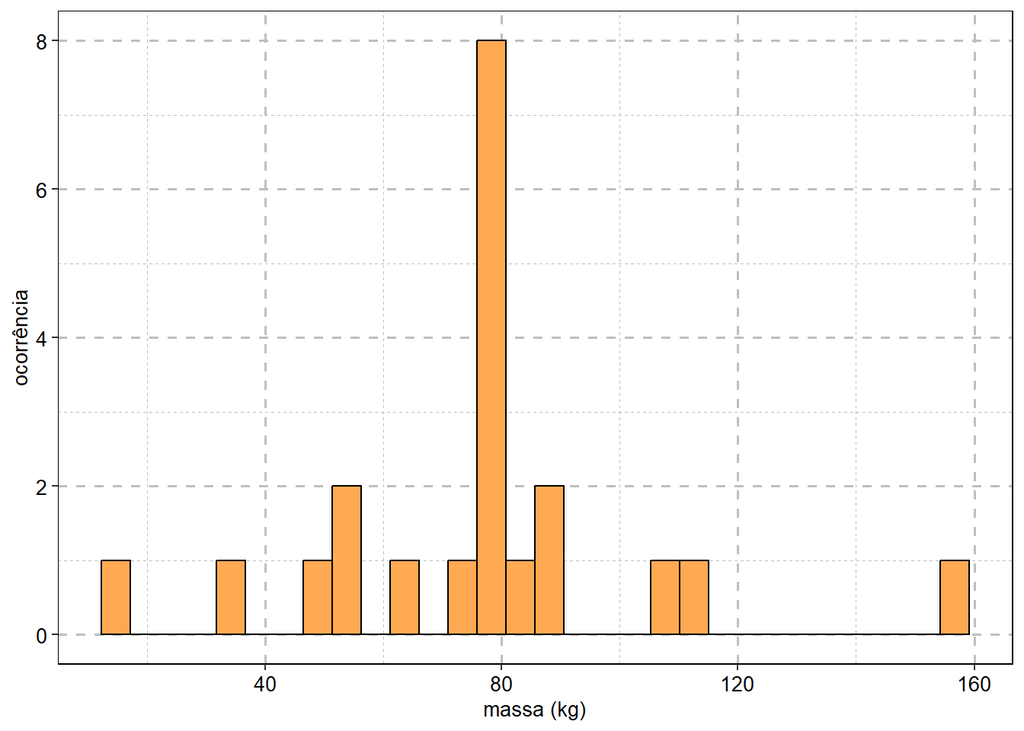

```r
starwars %>%
  filter(skin_color %in% amostra_cordepele) %>%
  ggplot(aes(mass))+
  geom_histogram(color="black",fill="#FFAA52")+
  labs(x="massa (kg)",
       y="ocorrência")+
  theme(text=element_text(family="TimesNewRoman"),
            title=element_text(color="black",size=15),
            axis.text = element_text(color="black",size=10),
            axis.title = element_text(color="black",size=10),
            panel.grid=element_line(color="grey75",linetype="dashed",size=0.7),
            axis.line=element_blank(),
            plot.background=element_rect(fill="white",color="white"),
            panel.background=element_rect(fill="white"),
            panel.border = element_rect(colour = "black",fill=NA,size=0.5),
            legend.key= element_rect(color="white",fill="white"))
```

Como mostrado no gráfico, na amostra coletada, a maior parte das ocorrências tiveram uma massa na faixa de ~70-90 Kg, sendo 80 Kg o ápice das ocorrências. Se fosse feito novamente, tería-se outra distribuição, pois seria outra amostra, mesmo que um pouco semelhante.

```r
amostra_cordepele2<-starwars$skin_color %>%
  sample(size=10)

amostra_cordepele2
```

```
##  [1] "pale"        "green"       "white, blue" "green"       "white"
##  [6] "fair"        "fair"        "orange"      "blue"        "orange"
```

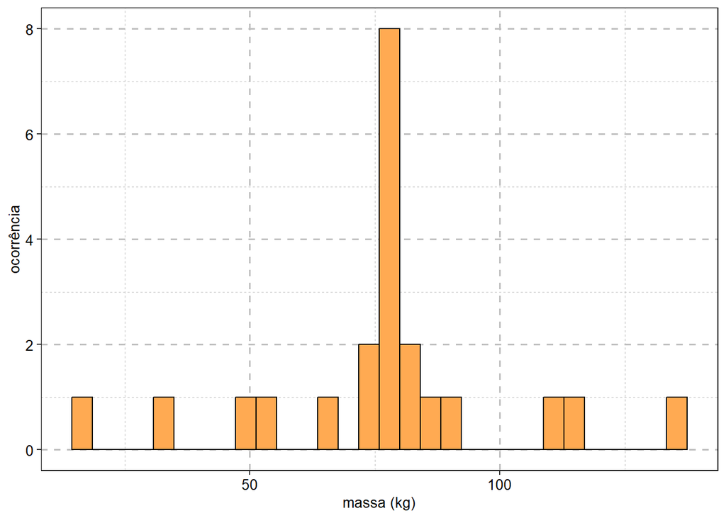

```r
starwars %>%
  filter(skin_color %in% amostra_cordepele2) %>%
  ggplot(aes(mass))+
  geom_histogram(color="black",fill="#FFAA52")+
  labs(x="massa (kg)",
       y="ocorrência")+
  theme(text=element_text(family="TimesNewRoman"),
            title=element_text(color="black",size=15),
            axis.text = element_text(color="black",size=10),
            axis.title = element_text(color="black",size=10),
            panel.grid=element_line(color="grey75",linetype="dashed",size=0.7),
            axis.line=element_blank(),
            plot.background=element_rect(fill="white",color="white"),
            panel.background=element_rect(fill="white"),
            panel.border = element_rect(colour = "black",fill=NA,size=0.5),
            legend.key= element_rect(color="white",fill="white"))
```

## 11.8 Sequência de laços de repetição

Sequências de repetição não condicionais apenas repetem um conjunto de tarefas de uma vez, não importando nenhuma suposta condição. São operações muito utilizadas quando você possui uma quantidade de tarefas a serem repetidas, baseando-se nos elementos de um conjunto de dados. Exemplo clássico: você possui uma base de dados com mais de 30 variáveis, sendo estas 1 é uma variável categória com dados binários (1 e 0) para a presença (1) ou não-presença (0) de um animal em uma região (lembrando que “ausência”, na ecologia, é algo dificil de ser mensurado, então “não presença” é um termo mais adequado), as outras 29 são variáveis numéricas contínuas sobre variáveis ambientais do local, e o seu trabalho é calcular a regressão logística simples da influência de cada uma das variáveis no comportamento da variável categórica. Existe o jeito padrão, que seria apenas repetir a operação, substituíndo apenas a variável no processo. Contudo, um jeito que poupa tempo são criando `laços de repetição`.

Laço de repetição `for` está na base da lógica de programação, não apenas da linguagem R, mas também de outras linguagens de programação. O que o laço `for()` faz é pegar os elementos em um vetor, e em seguida executar uma sequência de operações postas no comando, gerando assim uma sequência de resultados. normalmente, para informmar que serão trabalhados com os elementos de um vetor, usa-se o argumento `i` para o vetor, sendo então `i in 1:10` significa que serão feitas operações com todos os numéros entre 1 a 10.

Para exemplificar, nesse exemplo abaixo serão printados os numéros que aparecem numa sequência de números de 1 a 10. na função `for()`, importante notar que os comandos estarão entre as chaves `{ }`, enquanto que o vetor e a condição estarão entre os parênteses `( )`. outra coisa importante é que, caso deseje-se que os comandos pareçam como resultados, como `outputs`, é necessário usar a função `print()`.

```r
for(i in 1:10){

  print(i)

}
```

```
## [1] 1
## [1] 2
## [1] 3
## [1] 4
## [1] 5
## [1] 6
## [1] 7
## [1] 8
## [1] 9
## [1] 10
```

Para exemplificar melhor o que se pode ser feito, agora cada elemento do vetor será elevado ao quadrado e, em seguida, ao cubp.

```r
for(i in 1:10){

  print(i^2)

  print(i^3)
}
```

```
## [1] 1
## [1] 1
## [1] 4
## [1] 8
## [1] 9
## [1] 27
## [1] 16
## [1] 64
## [1] 25
## [1] 125
## [1] 36
## [1] 216
## [1] 49
## [1] 343
## [1] 64
## [1] 512
## [1] 81
## [1] 729
## [1] 100
## [1] 1000
```

Agora será feita uma coisa mais avançada: com o dataset `iris`, será feito um gráfico de boxplot sobre cada uma das variáveis contínuas, sobre o comprimento e largura das sépalas e pétalas para a variável categórica das espécies. Primeiramente, foram selecionadas apenas as variáveis númericas, utilizando a função `select_if()` com o comando `is.numeric` no dataser. Em seguida, dentro dos comandos, foi criado os comandos em [ggplot](https://rpubs.com/Edbbio/974391), onde na variável dependente, a variável Y, foi utilizado o comando `i`. para indicar que estariam sendo trabalhados as variáveis selecionadas. Por fim, foi adicionado um `print()`, para plotar os gráficos como `output`.

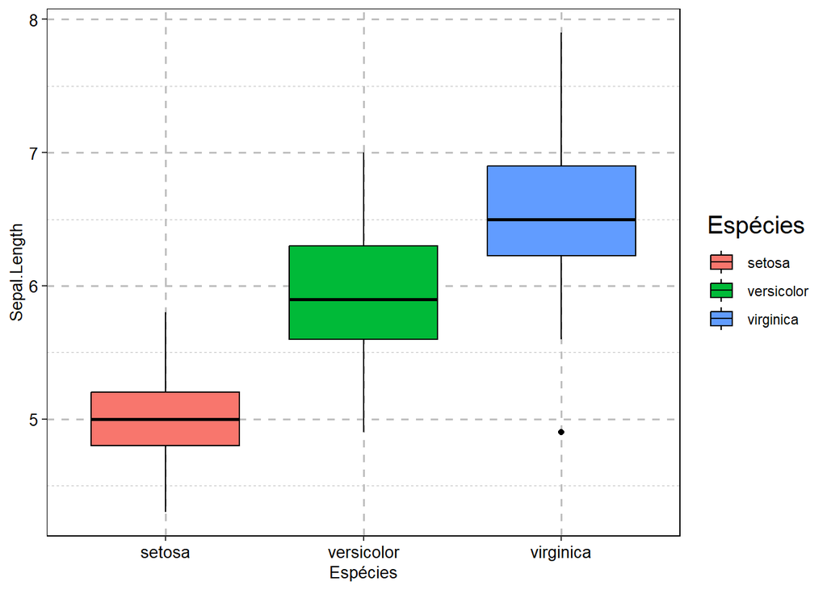

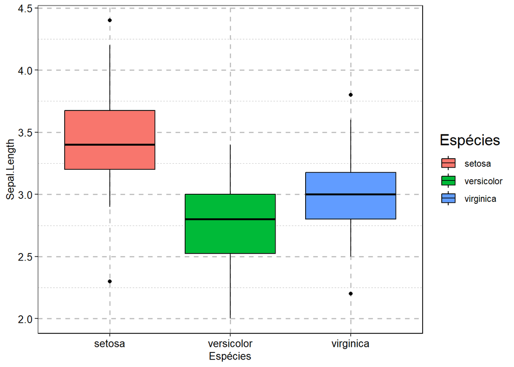

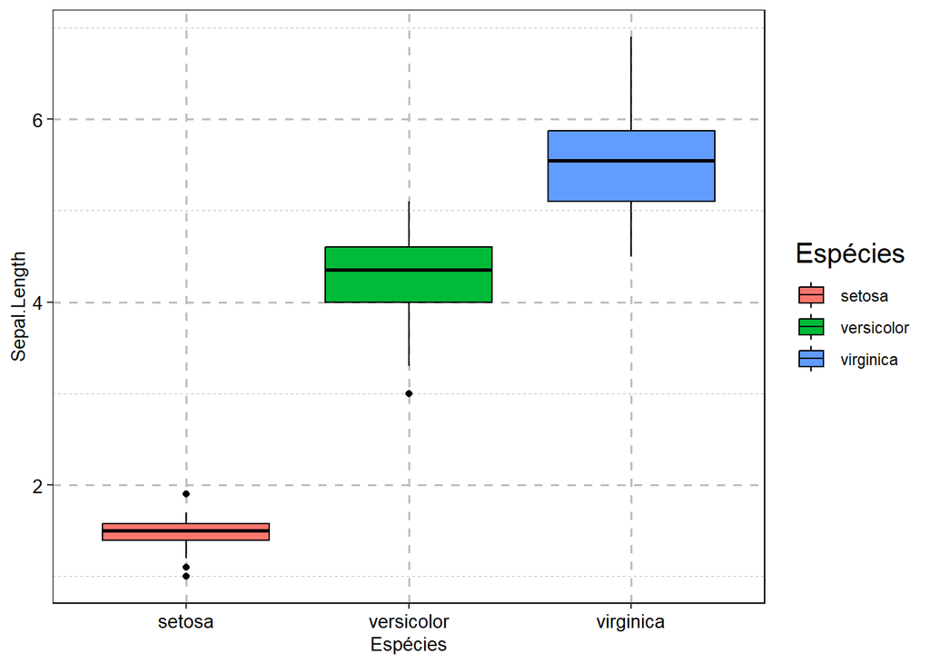

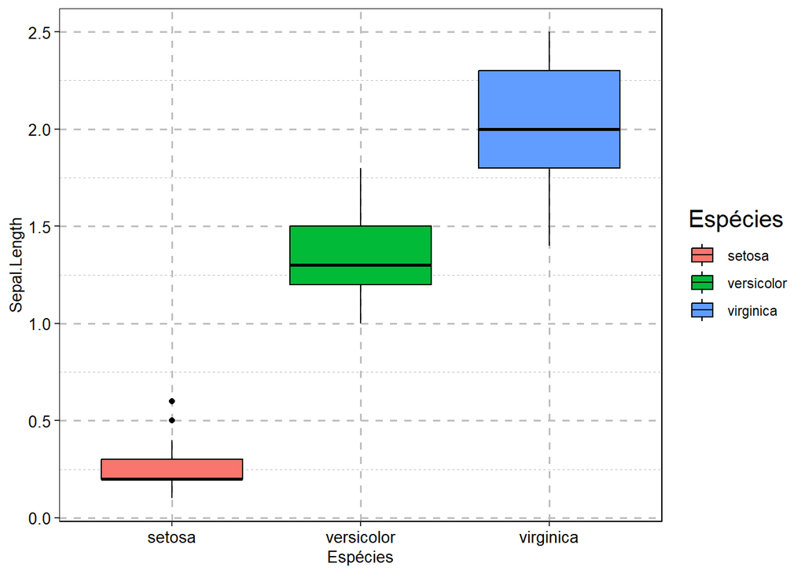

```r
for(i in iris %>% select_if(is.numeric)){

  print(iris %>%
          ggplot(aes(Species,i,fill=Species))+
          geom_boxplot(color="black")+
          labs(x="Espécies",
               y=colnames(iris),
               fill="Espécies")+
          theme(text=element_text(family="TimesNewRoman"),
            title=element_text(color="black",size=15),
            axis.text = element_text(color="black",size=10),
            axis.title = element_text(color="black",size=10),
            panel.grid=element_line(color="grey75",linetype="dashed",size=0.7),
            axis.line=element_blank(),
            plot.background=element_rect(fill="white",color="white"),
            panel.background=element_rect(fill="white"),
            panel.border = element_rect(colour = "black",fill=NA,size=0.5),
            legend.key= element_rect(color="white",fill="white")))

}
```

Sabendo onde posicionar o argumento `i` e o que fazer com ele, é possível fazer várias tarefas de uma vez. Outro exemplo, agora estatístico, é testar se há diferença nos comprimentos e larguras das sépalas e pétalas em relação à espécie. Para isso, será feito um teste ANOVA, utilizando o `for()` para fazer as repetições.

```r
for(i in iris %>% select_if(is.numeric)){

  print(aov(i~Species,data=iris) %>%
          summary())

}
```

```
##              Df Sum Sq Mean Sq F value Pr(>F)
## Species       2  63.21  31.606   119.3 <2e-16 ***
## Residuals   147  38.96   0.265
## ---
## Signif. codes:  0 '***' 0.001 '**' 0.01 '*' 0.05 '.' 0.1 ' ' 1
##              Df Sum Sq Mean Sq F value Pr(>F)
## Species       2  11.35   5.672   49.16 <2e-16 ***
## Residuals   147  16.96   0.115
## ---
## Signif. codes:  0 '***' 0.001 '**' 0.01 '*' 0.05 '.' 0.1 ' ' 1
##              Df Sum Sq Mean Sq F value Pr(>F)
## Species       2  437.1  218.55    1180 <2e-16 ***
## Residuals   147   27.2    0.19
## ---
## Signif. codes:  0 '***' 0.001 '**' 0.01 '*' 0.05 '.' 0.1 ' ' 1
##              Df Sum Sq Mean Sq F value Pr(>F)
## Species       2  80.41   40.21     960 <2e-16 ***
## Residuals   147   6.16    0.04
## ---
## Signif. codes:  0 '***' 0.001 '**' 0.01 '*' 0.05 '.' 0.1 ' ' 1
```

Como observado acima, há uma influência da espécie para a largura e o comprimento das sépalas e das pétalas (p<0,01). Contudo, vale ressaltar também que a ordem com que os elementos aparecem correspondem com a órdem dos elementos no vetor. Por isso, é importante correcer a ordem dos elementos no vetor que estão sendo trabalhados.

### 11.8.1 Criação de objetos com laço `for`

Na seção sobre `Alterando a ordem dos valores das variáveis de um dataset`, para alterar a órdem dos valores de uma órdem aleatória, foi criado objetos filtrando os valores da variável. Mas foram filtrados 1 por vez. Isso não é nenhum pouco prático, mas é possível criar os mesmos objetos de forma mais rápida utilizando o laço `for`. Para isso, será criado um vetor contendo os valores da variável, através da função `unique()` que exclui valores repitidos, um vetor contendo os objetos para onde as filtragens irão, através da função `paste0()`, e a filtragem, coma função `filter()` na função `assign()`, que cria novos objetos contendo valores especificados na fuunção, tudo no laço `for`.

```r
for(i in starwars$hair_color %>% unique()){

  objetos <- paste0(i, "_objeto")

  assign(objetos,
         starwars %>%
           filter(hair_color %in% i))
}
```

Com os objetos já criados, basta apenas reordena-los, através da função `rbind()`.

```r
starwars_reordenado <- rbind(blond_objeto,blonde_objeto,auburn_objeto,`auburn, grey_objeto`,`auburn, white_objeto`,brown_objeto,`brown, grey_objeto`,black_objeto,grey_objeto,white_objeto,unknown_objeto,none_objeto, NA_objeto)

starwars_reordenado
```

```
## # A tibble: 87 × 14
##    name        height  mass hair_…¹ skin_…² eye_c…³ birth…⁴ sex   gender homew…⁵
##    <chr>        <int> <dbl> <chr>   <chr>   <chr>     <dbl> <chr> <chr>  <chr>
##  1 Luke Skywa…    172    77 blond   fair    blue       19   male  mascu… Tatooi…
##  2 Anakin Sky…    188    84 blond   fair    blue       41.9 male  mascu… Tatooi…
##  3 Finis Valo…    170    NA blond   fair    blue       91   male  mascu… Corusc…
##  4 Zam Wesell     168    55 blonde  fair, … yellow     NA   fema… femin… Zolan
##  5 Mon Mothma     150    NA auburn  fair    blue       48   fema… femin… Chandr…
##  6 Wilhuff Ta…    180    NA auburn… fair    blue       64   male  mascu… Eriadu
##  7 Obi-Wan Ke…    182    77 auburn… fair    blue-g…    57   male  mascu… Stewjon
##  8 Leia Organa    150    49 brown   light   brown      19   fema… femin… Aldera…
##  9 Beru White…    165    75 brown   light   blue       47   fema… femin… Tatooi…
## 10 Chewbacca      228   112 brown   unknown blue      200   male  mascu… Kashyy…
## # … with 77 more rows, 4 more variables: species <chr>, films <list>,
## #   vehicles <list>, starships <list>, and abbreviated variable names
## #   ¹hair_color, ²skin_color, ³eye_color, ⁴birth_year, ⁵homeworld
```

Desta forma, o trabalho fica mais prático e automatizado.

# 12 **Tratando caracteres dos dados (`strings`)**

Ao trabalhar com dados que não são numéricos, como os dados caracteres (formato `charater`), é comum sistuações onde os dados em si não são os mesmos, mas apresentam certas semelhanças nos caracteres, nos seus `strings`. Exemplo: em uma base de dados, há uma variável para as cores encontrados em anfíbios.

```r
data.frame(cor=c("verde","amarelo","marrom","verde, amarelo","amarelo, marrom","preto","amarelo, preto"),indivíduo=paste0("indivíduo ",1:7))
```

```
##               cor   indivíduo
## 1           verde indivíduo 1
## 2         amarelo indivíduo 2
## 3          marrom indivíduo 3
## 4  verde, amarelo indivíduo 4
## 5 amarelo, marrom indivíduo 5
## 6           preto indivíduo 6
## 7  amarelo, preto indivíduo 7
```

Note que em uma mesma observação pode haver mais de uma cor. Se o objetivo fosse filtrar os indivíduos com cor `amarelo`, por exemplo, ao usar a função `filter()` para as ocorrências, os indivíduos 4, 5 e 7 ficariam de fora. Situações como estas podem ocorrer, onde a informação relevante não é a observação completa, mas `strings` específicos da observação. Para isso, é necessário filtrar os strings. Atualmente na linguagem de programação R, o pacote `stringr`, que pertence ao grupo do `Tidyverse`, é o que apresenta as principais ferramentas para estas situações.

Contudo, antes de começar, é importante ressalatar alguns pontos: assim como em outras linguagens de programação orientadas a objetos, na linguagem R, a forma como um string é escrito importa, então `a` não é o mesmo de `A`, assim como `2` não é a mesma coisa de `2.0`. Procure atentar-se a isso quando for trabalhar com strings.

## 12.1 Pacotes exigidos

```r
library(tidyverse)
```

## 12.2 Carregando os datasets

```r
data(starwars) # Dataset sobre personagens da franquia Starwars

head(starwars) # Visualizando os dados
```

```
## # A tibble: 6 × 14
##   name         height  mass hair_…¹ skin_…² eye_c…³ birth…⁴ sex   gender homew…⁵
##   <chr>         <int> <dbl> <chr>   <chr>   <chr>     <dbl> <chr> <chr>  <chr>
## 1 Luke Skywal…    172    77 blond   fair    blue       19   male  mascu… Tatooi…
## 2 C-3PO           167    75 <NA>    gold    yellow    112   none  mascu… Tatooi…
## 3 R2-D2            96    32 <NA>    white,… red        33   none  mascu… Naboo
## 4 Darth Vader     202   136 none    white   yellow     41.9 male  mascu… Tatooi…
## 5 Leia Organa     150    49 brown   light   brown      19   fema… femin… Aldera…
## 6 Owen Lars       178   120 brown,… light   blue       52   male  mascu… Tatooi…
## # … with 4 more variables: species <chr>, films <list>, vehicles <list>,
## #   starships <list>, and abbreviated variable names ¹hair_color, ²skin_color,
## #   ³eye_color, ⁴birth_year, ⁵homeworld
```

## 12.3 Contando a quantidade de strings nas observações

É possível contar quantos strings um vector inteiro possui, assim como também seus valores individais, através da função `str_length()`, do pacote `stringr`.

### 12.3.1 De uma variável inteira

Para contar `TODOS` os strings de uma variável de um dataset, basta apenas selecionar a variável, com a função `select()`, do pacote `dplyr`, e em seguida utilizar a função `str_length()`.

```r
starwars %>%
  select(skin_color) %>%
  str_length()
```

```
## [1] 869
```

### 12.3.2 Para cada valor individual

Caso o que se deseje for contar a quantidade de strings para cada valor de uma variável, ao invés de usar a função `select()`, usa-se o operador `$`. Essa diferença ocorre porquê, ao usar a função `select()`, seleciona-se o formato daquele dataset (no caso do `starwars`, o formato `tibble`). Já com o operador `$`, a variável se trandforma num vetor em formato `character`.

```r
starwars$skin_color %>% str_length()
```

```
##  [1]  4  4 11  5  5  5  5 10  5  4  4  4  7  4  5 16  4  4  5  4  4  5  5  4  5
## [26] 12  4  4  5  4  4 13  4  6  4  5  4 10  9  4  4  3  4  4 10 11 19  4  4  5
## [51]  5  4  4  5  6  4  4  5  4  5  6  6  5  4  3  3 19  5  4  4  4 10 11 11  4
## [76] 16 12  5  5  4  4  4  5  5  4  7  5
```

## 12.4 Selecionando um grupo específicos de strings de um vetor

Uma coisa interessante dos strings é que é possível selecionar apenas uma parcelas de strings de um vetor. Exemplo: existe uma variável contendo os dados de espécies seguidos de um `_local`, e deseja-se extrair apenas o nome das espécies. Para isso, usa-se a função `str_sub()`.

### 12.4.1 Selecionando baseado nos primeios strings

Com o argumento `start=`, informa-se a partir de qual string começará a seleção. Nesse caso, começará a partir do 4º string.

```r
starwars$hair_color %>% str_sub(start=4)
```

```
##  [1] "nd"         NA           NA           "e"          "wn"
##  [6] "wn, grey"   "wn"         NA           "ck"         "urn, white"
## [11] "nd"         "urn, grey"  "wn"         "wn"         NA
## [16] NA           "wn"         "wn"         "te"         "y"
## [21] "ck"         "e"          "e"          "ck"         "e"
## [26] "e"          "urn"        "wn"         "wn"         "e"
## [31] "wn"         "e"          "nd"         "e"          "e"
## [36] "e"          "wn"         "ck"         "e"          "ck"
## [41] "ck"         "e"          "e"          "e"          "e"
## [46] "e"          "e"          "e"          "te"         "e"
## [51] "ck"         "e"          "e"          "e"          "e"
## [56] "e"          "ck"         "wn"         "wn"         "e"
## [61] "ck"         "ck"         "wn"         "te"         "ck"
## [66] "ck"         "nde"        "e"          "e"          "e"
## [71] "te"         "e"          "e"          "e"          "e"
## [76] "e"          "e"          "wn"         "wn"         "e"
## [81] "e"          "ck"         "wn"         "wn"         "e"
## [86] "nown"       "wn"
```

### 12.4.2 Selecionando baseado nos últimos strings

O mesmo pode ser feito para os últimos strings, bastando apenas usar o argumento `end=`, informa-se a partir de qual string começará a seleção, mas agora selecionando os strings que antecedem a posição. Nesse caso, começará a partir do 3º string.

```r
starwars$hair_color %>% str_sub(end=3)
```

```
##  [1] "blo" NA    NA    "non" "bro" "bro" "bro" NA    "bla" "aub" "blo" "aub"
## [13] "bro" "bro" NA    NA    "bro" "bro" "whi" "gre" "bla" "non" "non" "bla"
## [25] "non" "non" "aub" "bro" "bro" "non" "bro" "non" "blo" "non" "non" "non"
## [37] "bro" "bla" "non" "bla" "bla" "non" "non" "non" "non" "non" "non" "non"
## [49] "whi" "non" "bla" "non" "non" "non" "non" "non" "bla" "bro" "bro" "non"
## [61] "bla" "bla" "bro" "whi" "bla" "bla" "blo" "non" "non" "non" "whi" "non"
## [73] "non" "non" "non" "non" "non" "bro" "bro" "non" "non" "bla" "bro" "bro"
## [85] "non" "unk" "bro"
```

### 12.4.3 Selecionado um intervalo específico de strings

Alternativamente, é possil selecionar um intervalo específico, informando a posição em que a selecão começará e a posição onde a seleção terminará. Nesse caso, começará no 2º string e terminará no 4º.

```r
starwars$hair_color %>% str_sub(2,4)
```

```
##  [1] "lon" NA    NA    "one" "row" "row" "row" NA    "lac" "ubu" "lon" "ubu"
## [13] "row" "row" NA    NA    "row" "row" "hit" "rey" "lac" "one" "one" "lac"
## [25] "one" "one" "ubu" "row" "row" "one" "row" "one" "lon" "one" "one" "one"
## [37] "row" "lac" "one" "lac" "lac" "one" "one" "one" "one" "one" "one" "one"
## [49] "hit" "one" "lac" "one" "one" "one" "one" "one" "lac" "row" "row" "one"
## [61] "lac" "lac" "row" "hit" "lac" "lac" "lon" "one" "one" "one" "hit" "one"
## [73] "one" "one" "one" "one" "one" "row" "row" "one" "one" "lac" "row" "row"
## [85] "one" "nkn" "row"
```

## 12.5 Combinando strings

No caso de dois conjunto de dados contendo dados, como `character`, e o que se deseja for transformar tudo isso em uma coisa só, basta apenas usar a funçã `str_c()`, bastando apenas indicar no comando `sep=`o que irá separa-los. Nesse caso, apenas um .

```r
dataset_character_1 <- "basta apenas usar"

dataset_character_2 <- "a função str_c()"

str_c(dataset_character_1, dataset_character_2, sep=" ")
```

```
## [1] "basta apenas usar a função str_c()"
```

## 12.6 Substituindo strings

É comum os casos onde uma base de dados possuem observações contendo mais de um valor, separados com algum caractére, e este caractére está errado, como `;` no lugar de uma `,`, e vice-versa. Para estas situações, é possível alterar as strings através da função `str_replace()`. Para esse exemplo, no dataset `Starwars`, as observações as `,` serão substituídas por `&`, utilizando a função `mutate`.

```r
starwars_strreplace <- starwars %>%
  mutate(hair_color = str_replace(hair_color,
                                  ", ",
                                  " & "),
         skin_color = str_replace(hair_color,
                                  ", ",
                                  " & "))

starwars_strreplace
```

```
## # A tibble: 87 × 14
##    name        height  mass hair_…¹ skin_…² eye_c…³ birth…⁴ sex   gender homew…⁵
##    <chr>        <int> <dbl> <chr>   <chr>   <chr>     <dbl> <chr> <chr>  <chr>
##  1 Luke Skywa…    172    77 blond   blond   blue       19   male  mascu… Tatooi…
##  2 C-3PO          167    75 <NA>    <NA>    yellow    112   none  mascu… Tatooi…
##  3 R2-D2           96    32 <NA>    <NA>    red        33   none  mascu… Naboo
##  4 Darth Vader    202   136 none    none    yellow     41.9 male  mascu… Tatooi…
##  5 Leia Organa    150    49 brown   brown   brown      19   fema… femin… Aldera…
##  6 Owen Lars      178   120 brown … brown … blue       52   male  mascu… Tatooi…
##  7 Beru White…    165    75 brown   brown   blue       47   fema… femin… Tatooi…
##  8 R5-D4           97    32 <NA>    <NA>    red        NA   none  mascu… Tatooi…
##  9 Biggs Dark…    183    84 black   black   brown      24   male  mascu… Tatooi…
## 10 Obi-Wan Ke…    182    77 auburn… auburn… blue-g…    57   male  mascu… Stewjon
## # … with 77 more rows, 4 more variables: species <chr>, films <list>,
## #   vehicles <list>, starships <list>, and abbreviated variable names
## #   ¹hair_color, ²skin_color, ³eye_color, ⁴birth_year, ⁵homeworld
```

No caso de alterar toda a base de daods, basta apenas usar um laço `for`. Nesse caso, foi criada um noo dataset contendo todas as informações do dataset `starwars`, e em seguida usado a função `str_replace`.

```r
for(i in colnames(starwars_strreplace <- starwars)){
  starwars_strreplace[[i]] <- starwars_strreplace[[i]] %>%
    str_replace(", ", " & ")
}

starwars_strreplace
```

```
## # A tibble: 87 × 14
##    name        height mass  hair_…¹ skin_…² eye_c…³ birth…⁴ sex   gender homew…⁵
##    <chr>       <chr>  <chr> <chr>   <chr>   <chr>   <chr>   <chr> <chr>  <chr>
##  1 Luke Skywa… 172    77    blond   fair    blue    19      male  mascu… Tatooi…
##  2 C-3PO       167    75    <NA>    gold    yellow  112     none  mascu… Tatooi…
##  3 R2-D2       96     32    <NA>    white … red     33      none  mascu… Naboo
##  4 Darth Vader 202    136   none    white   yellow  41.9    male  mascu… Tatooi…
##  5 Leia Organa 150    49    brown   light   brown   19      fema… femin… Aldera…
##  6 Owen Lars   178    120   brown … light   blue    52      male  mascu… Tatooi…
##  7 Beru White… 165    75    brown   light   blue    47      fema… femin… Tatooi…
##  8 R5-D4       97     32    <NA>    white … red     <NA>    none  mascu… Tatooi…
##  9 Biggs Dark… 183    84    black   light   brown   24      male  mascu… Tatooi…
## 10 Obi-Wan Ke… 182    77    auburn… fair    blue-g… 57      male  mascu… Stewjon
## # … with 77 more rows, 4 more variables: species <chr>, films <chr>,
## #   vehicles <chr>, starships <chr>, and abbreviated variable names
## #   ¹hair_color, ²skin_color, ³eye_color, ⁴birth_year, ⁵homeworld
```

## 12.7 Selecionado observações baseado em strings

Na parte que foi falada sobre filtragem de observações,foi falado que a função `filter()` e derivadas, como a função `filter_all(), filtra observações baseado nos seus valores. O ponto é que, se o valor que você tentar filtrar não for exatamente como está na observação, não retornará o esperado. Em algumas situações, as observações podem contar mais de uma informação. Um exemplo disso seria um dataset sobre as espécies encontradas em diferentes localidades, onde cada linha é uma localidade, e na variável que contem as espécies, uma observação contém maus de uma espécie. Como então filtrar as observações que contém mais de uma espécie? Nessas situações, não se filtra a observação, mas sim um grupo específico de strings.

### 12.7.1 Filtrando um grupo de strings de uma variável

```r
starwars
```

```
## # A tibble: 87 × 14
##    name        height  mass hair_…¹ skin_…² eye_c…³ birth…⁴ sex   gender homew…⁵
##    <chr>        <int> <dbl> <chr>   <chr>   <chr>     <dbl> <chr> <chr>  <chr>
##  1 Luke Skywa…    172    77 blond   fair    blue       19   male  mascu… Tatooi…
##  2 C-3PO          167    75 <NA>    gold    yellow    112   none  mascu… Tatooi…
##  3 R2-D2           96    32 <NA>    white,… red        33   none  mascu… Naboo
##  4 Darth Vader    202   136 none    white   yellow     41.9 male  mascu… Tatooi…
##  5 Leia Organa    150    49 brown   light   brown      19   fema… femin… Aldera…
##  6 Owen Lars      178   120 brown,… light   blue       52   male  mascu… Tatooi…
##  7 Beru White…    165    75 brown   light   blue       47   fema… femin… Tatooi…
##  8 R5-D4           97    32 <NA>    white,… red        NA   none  mascu… Tatooi…
##  9 Biggs Dark…    183    84 black   light   brown      24   male  mascu… Tatooi…
## 10 Obi-Wan Ke…    182    77 auburn… fair    blue-g…    57   male  mascu… Stewjon
## # … with 77 more rows, 4 more variables: species <chr>, films <list>,
## #   vehicles <list>, starships <list>, and abbreviated variable names
## #   ¹hair_color, ²skin_color, ³eye_color, ⁴birth_year, ⁵homeworld
```

No dataset `starwars`, as variáveis da cor do cabelo (`hair_color`) e cor da pele (`skin_color`) possuem observações com mais de uma cor. Num exemplo, como filtrar da variável da cor do cabelo os personagens com cor de cabelo marrom (`brown`), seja ela apenas ou mais alguma cor junto? Para estas questões, usa-se a função função `str_detect()`. Nessa função, basta apenas primeiro informar a variável desejada, e em seguida o grupo de strings desejados.

```r
starwars %>%
  filter(str_detect(hair_color,"brown"))
```

```
## # A tibble: 19 × 14
##    name        height  mass hair_…¹ skin_…² eye_c…³ birth…⁴ sex   gender homew…⁵
##    <chr>        <int> <dbl> <chr>   <chr>   <chr>     <dbl> <chr> <chr>  <chr>
##  1 Leia Organa    150    49 brown   light   brown        19 fema… femin… Aldera…
##  2 Owen Lars      178   120 brown,… light   blue         52 male  mascu… Tatooi…
##  3 Beru White…    165    75 brown   light   blue         47 fema… femin… Tatooi…
##  4 Chewbacca      228   112 brown   unknown blue        200 male  mascu… Kashyy…
##  5 Han Solo       180    80 brown   fair    brown        29 male  mascu… Corell…
##  6 Wedge Anti…    170    77 brown   fair    hazel        21 male  mascu… Corell…
##  7 Jek Tono P…    180   110 brown   fair    blue         NA male  mascu… Bestin…
##  8 Arvel Cryn…     NA    NA brown   fair    brown        NA male  mascu… <NA>
##  9 Wicket Sys…     88    20 brown   brown   brown         8 male  mascu… Endor
## 10 Qui-Gon Ji…    193    89 brown   fair    blue         92 male  mascu… <NA>
## 11 Ric Olié       183    NA brown   fair    blue         NA <NA>  <NA>   Naboo
## 12 Cordé          157    NA brown   light   brown        NA fema… femin… Naboo
## 13 Cliegg Lars    183    NA brown   fair    blue         82 male  mascu… Tatooi…
## 14 Dormé          165    NA brown   light   brown        NA fema… femin… Naboo
## 15 Tarfful        234   136 brown   brown   blue         NA male  mascu… Kashyy…
## 16 Raymus Ant…    188    79 brown   light   brown        NA male  mascu… Aldera…
## 17 Rey             NA    NA brown   light   hazel        NA fema… femin… <NA>
## 18 Poe Dameron     NA    NA brown   light   brown        NA male  mascu… <NA>
## 19 Padmé Amid…    165    45 brown   light   brown        46 fema… femin… Naboo
## # … with 4 more variables: species <chr>, films <list>, vehicles <list>,
## #   starships <list>, and abbreviated variable names ¹hair_color, ²skin_color,
## #   ³eye_color, ⁴birth_year, ⁵homeworld
```

### 12.7.2 Filtrando mais de um grupo de strings de uma variável

Existe também a possibilidade de filtrar mais de um grupo de strings. Semelhante ao ue foi feito anteriormente, baste apenas usar um, entre aspas, um `|` a cada grupo de strings desejados. Nesse exemplo, como o que se deseja é filtrar as observações com as cores marrom e branca, usa-se `"brown|white"`.

```r
starwars %>%
  filter(str_detect(hair_color,"brown|white"))
```

```
## # A tibble: 24 × 14
##    name        height  mass hair_…¹ skin_…² eye_c…³ birth…⁴ sex   gender homew…⁵
##    <chr>        <int> <dbl> <chr>   <chr>   <chr>     <dbl> <chr> <chr>  <chr>
##  1 Leia Organa    150    49 brown   light   brown        19 fema… femin… Aldera…
##  2 Owen Lars      178   120 brown,… light   blue         52 male  mascu… Tatooi…
##  3 Beru White…    165    75 brown   light   blue         47 fema… femin… Tatooi…
##  4 Obi-Wan Ke…    182    77 auburn… fair    blue-g…      57 male  mascu… Stewjon
##  5 Chewbacca      228   112 brown   unknown blue        200 male  mascu… Kashyy…
##  6 Han Solo       180    80 brown   fair    brown        29 male  mascu… Corell…
##  7 Wedge Anti…    170    77 brown   fair    hazel        21 male  mascu… Corell…
##  8 Jek Tono P…    180   110 brown   fair    blue         NA male  mascu… Bestin…
##  9 Yoda            66    17 white   green   brown       896 male  mascu… <NA>
## 10 Arvel Cryn…     NA    NA brown   fair    brown        NA male  mascu… <NA>
## # … with 14 more rows, 4 more variables: species <chr>, films <list>,
## #   vehicles <list>, starships <list>, and abbreviated variable names
## #   ¹hair_color, ²skin_color, ³eye_color, ⁴birth_year, ⁵homeworld
```

### 12.7.3 Filtrando grupos de strings de mais de uma variável

Agora será filtrado as observações com os strings `brown` para a variável de cor do cabelo e os strings `white` para a cor de pele. Como falado na sessão de filtragem de observações, ao fazer seleção de mais de uma variável pela função `filter()`, os comandos `&` e `|` tem diferenças. Nesse caos, como podem ser observações contendo uma das condições ou as duas ao mesmo tempo, usará o comando `|` para os comandos para a função `str_detect()`.

```r
starwars %>%
  filter(str_detect(hair_color,"brown") | str_detect(skin_color,"white"))
```

```
## # A tibble: 26 × 14
##    name        height  mass hair_…¹ skin_…² eye_c…³ birth…⁴ sex   gender homew…⁵
##    <chr>        <int> <dbl> <chr>   <chr>   <chr>     <dbl> <chr> <chr>  <chr>
##  1 R2-D2           96    32 <NA>    white,… red        33   none  mascu… Naboo
##  2 Darth Vader    202   136 none    white   yellow     41.9 male  mascu… Tatooi…
##  3 Leia Organa    150    49 brown   light   brown      19   fema… femin… Aldera…
##  4 Owen Lars      178   120 brown,… light   blue       52   male  mascu… Tatooi…
##  5 Beru White…    165    75 brown   light   blue       47   fema… femin… Tatooi…
##  6 R5-D4           97    32 <NA>    white,… red        NA   none  mascu… Tatooi…
##  7 Chewbacca      228   112 brown   unknown blue      200   male  mascu… Kashyy…
##  8 Han Solo       180    80 brown   fair    brown      29   male  mascu… Corell…
##  9 Wedge Anti…    170    77 brown   fair    hazel      21   male  mascu… Corell…
## 10 Jek Tono P…    180   110 brown   fair    blue       NA   male  mascu… Bestin…
## # … with 16 more rows, 4 more variables: species <chr>, films <list>,
## #   vehicles <list>, starships <list>, and abbreviated variable names
## #   ¹hair_color, ²skin_color, ³eye_color, ⁴birth_year, ⁵homeworld
```

### 12.7.4 Filtrando um grupo de strings para qualquer variável do dataset que o contenha

No caso de um grupo de strings de interesse estiver espalhado para várias variáveis, e ao invés de selecionar variável por variável, uma alternativa é utilizar o função `any_vars()`, junto com a função `filter_all()`, como já foi feito na sessão de filtragem, no começo dessa apostila. Nesse caso, serão selecionadas todas as observações que contiverem o grupo de strings `fem`, para selecionar tanto o sexo quanto o gênero feminino.

```r
starwars %>%
  filter_all(any_vars(str_detect(.,"fem")))
```

```
## # A tibble: 17 × 14
##    name        height  mass hair_…¹ skin_…² eye_c…³ birth…⁴ sex   gender homew…⁵
##    <chr>        <int> <dbl> <chr>   <chr>   <chr>     <dbl> <chr> <chr>  <chr>
##  1 Leia Organa    150  49   brown   light   brown        19 fema… femin… Aldera…
##  2 Beru White…    165  75   brown   light   blue         47 fema… femin… Tatooi…
##  3 Mon Mothma     150  NA   auburn  fair    blue         48 fema… femin… Chandr…
##  4 Shmi Skywa…    163  NA   black   fair    brown        72 fema… femin… Tatooi…
##  5 Ayla Secura    178  55   none    blue    hazel        48 fema… femin… Ryloth
##  6 Adi Gallia     184  50   none    dark    blue         NA fema… femin… Corusc…
##  7 Cordé          157  NA   brown   light   brown        NA fema… femin… Naboo
##  8 Luminara U…    170  56.2 black   yellow  blue         58 fema… femin… Mirial
##  9 Barriss Of…    166  50   black   yellow  blue         40 fema… femin… Mirial
## 10 Dormé          165  NA   brown   light   brown        NA fema… femin… Naboo
## 11 Zam Wesell     168  55   blonde  fair, … yellow       NA fema… femin… Zolan
## 12 Taun We        213  NA   none    grey    black        NA fema… femin… Kamino
## 13 Jocasta Nu     167  NA   white   fair    blue         NA fema… femin… Corusc…
## 14 R4-P17          96  NA   none    silver… red, b…      NA none  femin… <NA>
## 15 Shaak Ti       178  57   none    red, b… black        NA fema… femin… Shili
## 16 Rey             NA  NA   brown   light   hazel        NA fema… femin… <NA>
## 17 Padmé Amid…    165  45   brown   light   brown        46 fema… femin… Naboo
## # … with 4 more variables: species <chr>, films <list>, vehicles <list>,
## #   starships <list>, and abbreviated variable names ¹hair_color, ²skin_color,
## #   ³eye_color, ⁴birth_year, ⁵homeworld
```

### 12.7.5 Filtrando por exclusão de um grupo de strings

De forma semelhante à outras exclusões em filtragens de observações, basta apenas adicionar um `!` a frente da função `str_detect()`.

```r
starwars %>%
  filter(!str_detect(hair_color,"brown"))
```

```
## # A tibble: 63 × 14
##    name        height  mass hair_…¹ skin_…² eye_c…³ birth…⁴ sex   gender homew…⁵
##    <chr>        <int> <dbl> <chr>   <chr>   <chr>     <dbl> <chr> <chr>  <chr>
##  1 Luke Skywa…    172  77   blond   fair    blue       19   male  mascu… Tatooi…
##  2 Darth Vader    202 136   none    white   yellow     41.9 male  mascu… Tatooi…
##  3 Biggs Dark…    183  84   black   light   brown      24   male  mascu… Tatooi…
##  4 Obi-Wan Ke…    182  77   auburn… fair    blue-g…    57   male  mascu… Stewjon
##  5 Anakin Sky…    188  84   blond   fair    blue       41.9 male  mascu… Tatooi…
##  6 Wilhuff Ta…    180  NA   auburn… fair    blue       64   male  mascu… Eriadu
##  7 Yoda            66  17   white   green   brown     896   male  mascu… <NA>
##  8 Palpatine      170  75   grey    pale    yellow     82   male  mascu… Naboo
##  9 Boba Fett      183  78.2 black   fair    brown      31.5 male  mascu… Kamino
## 10 IG-88          200 140   none    metal   red        15   none  mascu… <NA>
## # … with 53 more rows, 4 more variables: species <chr>, films <list>,
## #   vehicles <list>, starships <list>, and abbreviated variable names
## #   ¹hair_color, ²skin_color, ³eye_color, ⁴birth_year, ⁵homeworld
```